# MiniProjeto Data Science Academy - Bruno Borguesan

Baseado no miniprojeto desenvolvido durante o curso de Deep Learning I da Data Science Academy, que tem o objetivo de Prever o Cancelamento de Reservas em Hotéis. A partir desse miniprojeto foram aplicadas novas limpezas dos dados baseado numa análise do artigo base. Também foram testados diferentes algoritmos para fazer a predição, bem como diferentes parâmetros do miniprojeto base.

Com isso, foi possível melhorar a acurácia do miniprojeto base de 84% com loss em 33%, para 87% de acurácia com loss de 27%.

```python
# Versão da Linguagem Python
from platform import python_version
print('Versão da Linguagem Python Usada Neste Jupyter Notebook:', python_version())
```

```
Versão da Linguagem Python Usada Neste Jupyter Notebook: 3.8.5
```

### Mini-Projeto 3: Inteligência Artificial Para Prever o Cancelamento de Reservas em Hotéis

[figure not shown]

Você já se perguntou quando é a melhor época do ano para reservar um quarto de hotel? Ou a duração ideal da estadia para obter a melhor taxa diária? E se você quisesse prever se é provável que um hotel receba um número desproporcionalmente alto de solicitações de cancelamento de reserva, durante uma pandemia, por exemplo?

Vamos usar Inteligência Artificial, especificamente Deep Learning, para prever o cancelamento de reservas em hotéis.

Usaremos um conjunto de dados que contém informações de reserva de um hotel urbano e de um hotel resort e inclui informações como quando a reserva foi feita, duração da estadia, número de adultos, data de chegada e número de vagas disponíveis, entre outras informações.

Todas as informações de identificação pessoal foram removidas dos dados.

O conjunto de dados é complexo e vai requerer um esforço adicional de limpeza e transformação dos dados. Ótimo para praticar essas habilidades.

Fonte de Dados:

[1] https://www.sciencedirect.com/science/article/pii/S2352340918315191

Leia cada comentário com atenção, estude as técnicas apresentadas, faça modificações, pratique, aprenda e divirta-se.

```python
!nvidia-smi
```

[output not shown]

```python
# Para atualizar um pacote, execute o comando abaixo no terminal ou prompt de comando:
# pip install -U nome_pacote

# Para instalar a versão exata de um pacote, execute o comando abaixo no terminal ou prompt de comando:
# pip install nome_pacote==versão_desejada

# Depois de instalar ou atualizar o pacote, reinicie o jupyter notebook.

# Instala o pacote watermark.
# Esse pacote é usado para gravar as versões de outros pacotes usados neste jupyter notebook.
#!pip install -q -U watermark

# Pacote para automação da análise exploratória
#!pip install -q pandas_profiling
```

```python
# Imports

# Imports para manipulação e visualização de dados
import numpy as np
import pandas as pd
import matplotlib as m
import matplotlib.pyplot as plt
import seaborn as sns
import pandas_profiling
from pandas_profiling import ProfileReport

# Imports para pré-processamento e avaliação
import sklearn
from sklearn.ensemble import RandomForestClassifier, GradientBoostingClassifier
from sklearn.model_selection import train_test_split, cross_val_score, GridSearchCV
from sklearn.preprocessing import MinMaxScaler, StandardScaler
from sklearn.metrics import accuracy_score, confusion_matrix
from sklearn.linear_model import LogisticRegression
from sklearn.pipeline import make_pipeline

# Imports para Deep Learning
import tensorflow
import keras
from keras.models import Sequential
from keras.layers import Dense, Input, Dropout, LeakyReLU
from keras.losses import categorical_crossentropy, binary_crossentropy
from keras.utils import to_categorical
from keras.callbacks import EarlyStopping, ReduceLROnPlateau
from keras.optimizers import Nadam
from keras.layers import BatchNormalization

# Imports para formatação dos gráficos
from matplotlib.pylab import rcParams
rcParams['axes.labelsize'] = 14
rcParams['xtick.labelsize'] = 12
rcParams['ytick.labelsize'] = 12
rcParams['text.color'] = 'k'
rcParams['figure.max_open_warning'] = 30
rcParams['figure.figsize'] = 10,8
m.style.use('ggplot')
%matplotlib inline
```

```python
# Versões dos pacotes usados neste jupyter notebook
%reload_ext watermark
%watermark -a "Data Science Academy" --iversions
```

```
Author: Data Science Academy

matplotlib      : 3.3.2
keras           : 2.4.3
seaborn         : 0.11.0
numpy           : 1.19.2
pandas_profiling: 2.10.0
pandas          : 1.1.3
tensorflow      : 2.4.0
sklearn         : 0.23.2
```

## Checando o Hardware Disponível no Servidor da DSA - CPU e GPUs

```python
# Lista todos os dispositivos disponiveis
from tensorflow.python.client import device_lib
print(device_lib.list_local_devices())
```

```
[name: "/device:CPU:0"
device_type: "CPU"
memory_limit: 268435456
locality {
}
incarnation: 9130497755973874560
, name: "/device:GPU:0"
device_type: "GPU"
memory_limit: 3047791003
locality {
  bus_id: 1
  links {
  }
}
incarnation: 7334899636625773910
physical_device_desc: "device: 0, name: GeForce GTX 1650, pci bus id: 0000:07:00.0, compute capability: 7.5"
]
```

> Se por acaso não aparecer para você todas as GPUs, reinstale o TensorFlow:

```python
# pip uninstall tensorflow
# pip install tensorflow
```

```python
import tensorflow as tf
print("Número Disponível de GPUs: ", len(tf.config.experimental.list_physical_devices('GPU')))
```

```
Número Disponível de GPUs:  1
```

```python
# Lista o código de cada GPU
tf.config.list_physical_devices('GPU')
```

```
[PhysicalDevice(name='/physical_device:GPU:0', device_type='GPU')]
```

## Carregando os Dados

```python
# Carrega o dataset
H1 = pd.read_csv("dados/H1.csv")
H1['Hotel'] = 'Resort Hotel'
# Carrega o dataset
H2 = pd.read_csv("dados/H2.csv")
H2['Hotel'] = 'City Hotel'
dataset = pd.concat([H1, H2], ignore_index=True)
```

```python
# Shape
dataset.shape
```

```
(119390, 32)
```

```python
# Visualiza os dados
dataset.head(5)
```

|  | IsCanceled | LeadTime | ArrivalDateYear | ArrivalDateMonth | ArrivalDateWeekNumber | ArrivalDateDayOfMonth | StaysInWeekendNights | StaysInWeekNights | Adults | Children | ... | Agent | Company | DaysInWaitingList | CustomerType | ADR | RequiredCarParkingSpaces | TotalOfSpecialRequests | ReservationStatus | ReservationStatusDate | Hotel |
| --- | --- | --- | --- | --- | --- | --- | --- | --- | --- | --- | --- | --- | --- | --- | --- | --- | --- | --- | --- | --- | --- |
| 0 | 0 | 342 | 2015 | July | 27 | 1 | 0 | 0 | 2 | 0.0 | ... | NULL | NULL | 0 | Transient | 0.0 | 0 | 0 | Check-Out | 2015-07-01 | Resort Hotel |
| 1 | 0 | 737 | 2015 | July | 27 | 1 | 0 | 0 | 2 | 0.0 | ... | NULL | NULL | 0 | Transient | 0.0 | 0 | 0 | Check-Out | 2015-07-01 | Resort Hotel |
| 2 | 0 | 7 | 2015 | July | 27 | 1 | 0 | 1 | 1 | 0.0 | ... | NULL | NULL | 0 | Transient | 75.0 | 0 | 0 | Check-Out | 2015-07-02 | Resort Hotel |
| 3 | 0 | 13 | 2015 | July | 27 | 1 | 0 | 1 | 1 | 0.0 | ... | 304 | NULL | 0 | Transient | 75.0 | 0 | 0 | Check-Out | 2015-07-02 | Resort Hotel |
| 4 | 0 | 14 | 2015 | July | 27 | 1 | 0 | 2 | 2 | 0.0 | ... | 240 | NULL | 0 | Transient | 98.0 | 0 | 1 | Check-Out | 2015-07-03 | Resort Hotel |

5 rows × 32 columns

```python
# Visualiza os dados
dataset.tail(5)
```

|  | IsCanceled | LeadTime | ArrivalDateYear | ArrivalDateMonth | ArrivalDateWeekNumber | ArrivalDateDayOfMonth | StaysInWeekendNights | StaysInWeekNights | Adults | Children | ... | Agent | Company | DaysInWaitingList | CustomerType | ADR | RequiredCarParkingSpaces | TotalOfSpecialRequests | ReservationStatus | ReservationStatusDate | Hotel |
| --- | --- | --- | --- | --- | --- | --- | --- | --- | --- | --- | --- | --- | --- | --- | --- | --- | --- | --- | --- | --- | --- |
| 119385 | 0 | 23 | 2017 | August | 35 | 30 | 2 | 5 | 2 | 0.0 | ... | 394 | NULL | 0 | Transient | 96.14 | 0 | 0 | Check-Out | 2017-09-06 | City Hotel |
| 119386 | 0 | 102 | 2017 | August | 35 | 31 | 2 | 5 | 3 | 0.0 | ... | 9 | NULL | 0 | Transient | 225.43 | 0 | 2 | Check-Out | 2017-09-07 | City Hotel |
| 119387 | 0 | 34 | 2017 | August | 35 | 31 | 2 | 5 | 2 | 0.0 | ... | 9 | NULL | 0 | Transient | 157.71 | 0 | 4 | Check-Out | 2017-09-07 | City Hotel |
| 119388 | 0 | 109 | 2017 | August | 35 | 31 | 2 | 5 | 2 | 0.0 | ... | 89 | NULL | 0 | Transient | 104.40 | 0 | 0 | Check-Out | 2017-09-07 | City Hotel |
| 119389 | 0 | 205 | 2017 | August | 35 | 29 | 2 | 7 | 2 | 0.0 | ... | 9 | NULL | 0 | Transient | 151.20 | 0 | 2 | Check-Out | 2017-09-07 | City Hotel |

5 rows × 32 columns

## Análise Exploratória

O Pandas Profiling gera um relatório completo de análise exploratória dos dados. Começamos por ele.

```python
# Foi tentado gerar o relatório completo, usando o comando abaixo, entretanto, devido à falta de poder computacional crashava na falta de memória;
# prof = ProfileReport(dataset)

# Foi tentado realizar tirando algumas funcionalidades do report, mas ainda assim produzia erros;
'''
prof = ProfileReport(df, minimal=True,
                     correlations={'pearson': {'calculate': False},
                                   'spearman': {'calculate': False},
                                   'kendall': {'calculate': False},
                                   'phi_k': {'calculate': False},
                                   'cramers': {'calculate': False}},
                     missing_diagrams={'heatmap': False,
                                       'dendrogram': False,
      })
'''
# Para contornar esse problema, realizamos um sample da amostra utilizando 50% dos dados e uma seed fixa para permitir a geração do ProfileReport, random_state=99
df = dataset.sample(frac=0.5, random_state=99)
df.shape
```

```
(59695, 32)
```

```python
# Gera relatório de análise exploratória
prof = ProfileReport(df)
```

```python
# Visualiza o relatório
prof
```

```python
# Salva o relatório em formato HTML
prof.to_file(output_file = 'relatorio.html')
```

> Utilizamos o 'df' criado apenas para gerar o relatório, o resto das operações continuaremos a usar o 'dataset' completo

```python
# Número de colunas
print(len(dataset.columns))
```

```
32
```

```python
# Tipos de dados
dataset.dtypes
```

```
IsCanceled                       int64
LeadTime                         int64
ArrivalDateYear                  int64
ArrivalDateMonth                object
ArrivalDateWeekNumber            int64
ArrivalDateDayOfMonth            int64
StaysInWeekendNights             int64
StaysInWeekNights                int64
Adults                           int64
Children                       float64
Babies                           int64
Meal                            object
Country                         object
MarketSegment                   object
DistributionChannel             object
IsRepeatedGuest                  int64
PreviousCancellations            int64
PreviousBookingsNotCanceled      int64
ReservedRoomType                object
AssignedRoomType                object
BookingChanges                   int64
DepositType                     object
Agent                           object
Company                         object
DaysInWaitingList                int64
CustomerType                    object
ADR                            float64
RequiredCarParkingSpaces         int64
TotalOfSpecialRequests           int64
ReservationStatus               object
ReservationStatusDate           object
Hotel                           object
dtype: object
```

```python
# Vamos checar quais colunas são do tipo string
for column, series in dataset.items():
    if str(type(series[0])) == "<class 'str'>":
        print(column)
```

```
ArrivalDateMonth
Meal
Country
MarketSegment
DistributionChannel
ReservedRoomType
AssignedRoomType
DepositType
Agent
Company
CustomerType
ReservationStatus
ReservationStatusDate
Hotel
```

Não podemos levar valores no formato de texto para o treinamento do modelo. Vamos tratar isso daqui a pouco. Primeiro vamos checar se temos valores ausentes.

```python
# Total de valores ausentes por coluna
dataset.isnull().sum()
```

```
IsCanceled                       0
LeadTime                         0
ArrivalDateYear                  0
ArrivalDateMonth                 0
ArrivalDateWeekNumber            0
ArrivalDateDayOfMonth            0
StaysInWeekendNights             0
StaysInWeekNights                0
Adults                           0
Children                         4
Babies                           0
Meal                             0
Country                        488
MarketSegment                    0
DistributionChannel              0
IsRepeatedGuest                  0
PreviousCancellations            0
PreviousBookingsNotCanceled      0
ReservedRoomType                 0
AssignedRoomType                 0
BookingChanges                   0
DepositType                      0
Agent                            0
Company                          0
DaysInWaitingList                0
CustomerType                     0
ADR                              0
RequiredCarParkingSpaces         0
TotalOfSpecialRequests           0
ReservationStatus                0
ReservationStatusDate            0
Hotel                            0
dtype: int64
```

Sim, temos em algumas colunas. Então vamos ao processo de limpeza e transformação dos dados.

> "The PMS assured no missing data exists in its database tables. However, in some categorical variables like Agent or Company, “NULL” is presented as one of the categories. This should not be considered a missing value, but rather as “not applicable”. For example, if a booking “Agent” is defined as “NULL” it means that the booking did not came from a travel agent." [1] Trecho retirado do artigo dos dados...

```python
# Contar o numero de ocorrencia do valor NULL
dataset['Company'].value_counts()
```

```
       NULL    112593
         40       927
        223       784
         67       267
         45       250
                ...
        489         1
        541         1
        318         1
        454         1
        313         1
Name: Company, Length: 353, dtype: int64
```

```python
# Contar o numero de ocorrencia do valor NULL
dataset['Agent'].value_counts()
```

```
          9    31961
       NULL    16340
        240    13922
          1     7191
         14     3640
               ...
        114        1
        367        1
        267        1
        453        1
        216        1
Name: Agent, Length: 334, dtype: int64
```

## Limpeza e Transformação

A coluna 'Company' tem quase todos os registros NULL, apenas 6.797 possuem valor atribuído. Assim, mantemos a coluna e substituímos os valores nulos como '-1'. A coluna 'Agent' possui 16340 registros NULL. Assim, mantemos a coluna e substituímos os valores nulos como '-1'. Com isso, simbolizamos quando não usou 'Company' nem 'Agent' para fazer a reserva.

```python
# Substituir os valor nulos como '-1'.
dataset["Agent"] = dataset.Agent.apply(lambda x: x.strip())
dataset["Company"] = dataset.Company.apply(lambda x: x.strip())

dataset['Company'] = dataset['Company'].replace("NULL", -1)
dataset['Agent'] = dataset['Agent'].replace("NULL", -1)
```

Apesar do texto afirmar que não existem valores faltando alguns dados precisam ser alterados, por exemplo: A coluna 'Country' representa o pais de origem do hospede, contendo 488 registros NULL, entretanto, no texto não fica claro o que representariam esses valores nulos, bem como na Coluna 'Children' temos 4 registros nulos. Assim, optamos por remover as linhas com esses dados.

```python
# Removemos valores ausentes que ainda estverem no dataset
dataset = dataset.dropna()
```

```python
# Shape #118898 - 119390 = 492 -> 488 'Country' + 4 'Children'
dataset.shape
```

```
(118898, 32)
```

```python
# Total de valores ausentes por coluna
dataset.isnull().sum()
```

```
IsCanceled                     0
LeadTime                       0
ArrivalDateYear                0
ArrivalDateMonth               0
ArrivalDateWeekNumber          0
ArrivalDateDayOfMonth          0
StaysInWeekendNights           0
StaysInWeekNights              0
Adults                         0
Children                       0
Babies                         0
Meal                           0
Country                        0
MarketSegment                  0
DistributionChannel            0
IsRepeatedGuest                0
PreviousCancellations          0
PreviousBookingsNotCanceled    0
ReservedRoomType               0
AssignedRoomType               0
BookingChanges                 0
DepositType                    0
Agent                          0
Company                        0
DaysInWaitingList              0
CustomerType                   0
ADR                            0
RequiredCarParkingSpaces       0
TotalOfSpecialRequests         0
ReservationStatus              0
ReservationStatusDate          0
Hotel                          0
dtype: int64
```

Agora vamos trabalhar em outras variáveis. Temos muitas variáveis categóricas nesse dataset e teremos que tomar algumas ações.

Uma alternativa simples é aplicar o Label Encoding, ou seja, convertemos o texto em cada coluna para um valor numérico correspondente. Vamos ao trabalho.

**Encoding da variável com o mês de chegada no hotel.**

```python
# Valores únicos para a coluna de mês de chegada
dataset.ArrivalDateMonth.unique()
```

```
array(['July', 'August', 'September', 'October', 'November', 'December',
       'January', 'February', 'March', 'April', 'May', 'June'],
      dtype=object)
```

```python
# Dicionário de meses
mes_dict = {"January": 1,
            "February": 2,
            "March": 3,
            "April": 4,
            "May": 5,
            "June": 6,
            "July": 7,
            "August": 8,
            "September": 9,
            "October": 10,
            "November": 11,
            "December": 12}
```

```python
# Vamos converter os meses para o valor numérico correspondente, conforme colocamos no dicionário
dataset["ArrivalDateMonth"] = dataset.ArrivalDateMonth.apply(lambda x: mes_dict[x])
```

```python
# Total de registros para cada mês
dataset.ArrivalDateMonth.value_counts()
```

```
8     13852
7     12628
5     11779
10    11095
4     11045
6     10927
9     10467
3      9739
2      8012
11     6752
12     6728
1      5874
Name: ArrivalDateMonth, dtype: int64
```

Mês de Agosto teve o maior número de reservas e mês de Janeiro o menor. Isso se explica porque no hemisfério Norte o auge do Verão e as férias são em Agosto.

**Encoding das variáveis com tipo de quarto reservado e tipo de quarto ocupado.**

```python
# Valores únicos de quartos reservados
dataset.ReservedRoomType.sort_values().unique()
```

```
array(['A               ', 'B               ', 'C               ',
       'D               ', 'E               ', 'F               ',
       'G               ', 'H               ', 'L               ',
       'P               '], dtype=object)
```

```python
# Valores únicos de quartos já ocupados
dataset.AssignedRoomType.sort_values().unique()
```

```
array(['A               ', 'B               ', 'C               ',
       'D               ', 'E               ', 'F               ',
       'G               ', 'H               ', 'I               ',
       'K               ', 'L               ', 'P               '],
      dtype=object)
```

Vamos adotar a mesma estratégia usada com os meses.

```python
# Dicionário para o encoding do tipo de quarto
tipo_quarto_dict = {"A": 1, "B": 2, "C": 3, "D": 4, "E": 5, "F": 6, "G": 7, "H": 8, "I": 9, "J": 10, "K": 11, "L": 12, "M": 13, "N": 14, "O": 15, "P": 16}
```

```python
# Atribuímos o dicionário para fazer o encoding nas colunas com texto e criar as colunas numéricas; Usamos o strip para remover o espaço 'A               ' -> 'A'
dataset["reserved_room_type_numerical"] = dataset.ReservedRoomType.apply(lambda x: tipo_quarto_dict[x.strip()])
dataset["assigned_room_type_numerical"] = dataset.AssignedRoomType.apply(lambda x: tipo_quarto_dict[x.strip()])
```

```python
# Visualiza os dados
dataset.head()
```

|  | IsCanceled | LeadTime | ArrivalDateYear | ArrivalDateMonth | ArrivalDateWeekNumber | ArrivalDateDayOfMonth | StaysInWeekendNights | StaysInWeekNights | Adults | Children | ... | DaysInWaitingList | CustomerType | ADR | RequiredCarParkingSpaces | TotalOfSpecialRequests | ReservationStatus | ReservationStatusDate | Hotel | reserved_room_type_numerical | assigned_room_type_numerical |
| --- | --- | --- | --- | --- | --- | --- | --- | --- | --- | --- | --- | --- | --- | --- | --- | --- | --- | --- | --- | --- | --- |
| 0 | 0 | 342 | 2015 | 7 | 27 | 1 | 0 | 0 | 2 | 0.0 | ... | 0 | Transient | 0.0 | 0 | 0 | Check-Out | 2015-07-01 | Resort Hotel | 3 | 3 |
| 1 | 0 | 737 | 2015 | 7 | 27 | 1 | 0 | 0 | 2 | 0.0 | ... | 0 | Transient | 0.0 | 0 | 0 | Check-Out | 2015-07-01 | Resort Hotel | 3 | 3 |
| 2 | 0 | 7 | 2015 | 7 | 27 | 1 | 0 | 1 | 1 | 0.0 | ... | 0 | Transient | 75.0 | 0 | 0 | Check-Out | 2015-07-02 | Resort Hotel | 1 | 3 |
| 3 | 0 | 13 | 2015 | 7 | 27 | 1 | 0 | 1 | 1 | 0.0 | ... | 0 | Transient | 75.0 | 0 | 0 | Check-Out | 2015-07-02 | Resort Hotel | 1 | 1 |
| 4 | 0 | 14 | 2015 | 7 | 27 | 1 | 0 | 2 | 2 | 0.0 | ... | 0 | Transient | 98.0 | 0 | 1 | Check-Out | 2015-07-03 | Resort Hotel | 1 | 1 |

5 rows × 34 columns

Removemos as duas colunas com valores em texto.

```python
# Não precisamos mais das colunas "ReservedRoomType" e "AssignedRoomType", porque criamos a versão numérica
dataset = dataset.drop(["ReservedRoomType", "AssignedRoomType"], axis = 1)
```

**Encoding da variável com o tipo de depósito.**

```python
# Valores únicos da variável "deposit_type"
dataset.DepositType.unique()
```

```
array(['No Deposit     ', 'Refundable     ', 'Non Refund     '],
      dtype=object)
```

```python
# Dicionário
tipo_deposito_dict = {"No Deposit": 0, "Refundable": 1, "Non Refund": -1}
```

```python
# Aplicamos o encoding
dataset["DepositType"] = dataset.DepositType.apply(lambda x: tipo_deposito_dict[x.strip()])
```

**Encoding da variável com o tipo de cliente.**

```python
# Valores únicos
dataset.CustomerType.unique()
```

```
array(['Transient', 'Contract', 'Transient-Party', 'Group'], dtype=object)
```

```python
# Dicionário
tipo_cliente_dict = {"Transient": 0, "Contract": 1, "Transient-Party": 2, "Group":3}
```

```python
# Aplicamos o encoding
dataset["CustomerType"] = dataset.CustomerType.apply(lambda x: tipo_cliente_dict[x])
```

**Encoding da variável com o tipo de hotel.**

```python
# Valores únicos
dataset.Hotel.unique()
```

```
array(['Resort Hotel', 'City Hotel'], dtype=object)
```

```python
# Dicionário com o tipo de hotel
tipo_hotel_dict = {"Resort Hotel": 0, "City Hotel": 1}
```

```python
# Aplica o encoding e cria nova coluna
dataset["Hotel"] = dataset.Hotel.apply(lambda x: tipo_hotel_dict[x])
```

**Encoding da variável com o tipo de refeição.**

```python
# Valores únicos
dataset.Meal.unique()
```

```
array(['BB       ', 'FB       ', 'HB       ', 'SC       ', 'Undefined'],
      dtype=object)
```

```python
# Dicionário
tipo_refeicao_dict = {"BB": 0, "FB": 1, "HB": 2, "SC": 3, "Undefined": -1}
```

```python
# Aplica o encoding e cria nova coluna
dataset["Meal"] = dataset.Meal.apply(lambda x: tipo_refeicao_dict[x.strip()])
```

**Encoding da variável com o tipo de segmento de mercado.**

```python
# Valores únicos
dataset.MarketSegment.unique()
```

```
array(['Direct', 'Corporate', 'Online TA', 'Offline TA/TO',
       'Complementary', 'Groups', 'Aviation'], dtype=object)
```

```python
# Valores únicos
dataset.DistributionChannel.unique()
```

```
array(['Direct', 'Corporate', 'TA/TO', 'Undefined', 'GDS'], dtype=object)
```

```python
# Dicionário
segmento_mercado_dict = {"Direct": 0,
                         "Corporate": 1,
                         "Online TA": 2,
                         "Offline TA/TO": 3,
                         "Complementary": 4,
                         "Groups": 5,
                         "Aviation": 6,
                         "GDS": 7,
                         "TA/TO": 8,
                         "Undefined": -1}
```

```python
# Aplica o encoding
dataset["MarketSegment"] = dataset.MarketSegment.apply(lambda x: segmento_mercado_dict[x])
dataset["DistributionChannel"] = dataset.DistributionChannel.apply(lambda x: segmento_mercado_dict[x])
```

```python
# Visualiza os dados
dataset.head(5)
```

|  | IsCanceled | LeadTime | ArrivalDateYear | ArrivalDateMonth | ArrivalDateWeekNumber | ArrivalDateDayOfMonth | StaysInWeekendNights | StaysInWeekNights | Adults | Children | ... | DaysInWaitingList | CustomerType | ADR | RequiredCarParkingSpaces | TotalOfSpecialRequests | ReservationStatus | ReservationStatusDate | Hotel | reserved_room_type_numerical | assigned_room_type_numerical |
| --- | --- | --- | --- | --- | --- | --- | --- | --- | --- | --- | --- | --- | --- | --- | --- | --- | --- | --- | --- | --- | --- |
| 0 | 0 | 342 | 2015 | 7 | 27 | 1 | 0 | 0 | 2 | 0.0 | ... | 0 | 0 | 0.0 | 0 | 0 | Check-Out | 2015-07-01 | 0 | 3 | 3 |
| 1 | 0 | 737 | 2015 | 7 | 27 | 1 | 0 | 0 | 2 | 0.0 | ... | 0 | 0 | 0.0 | 0 | 0 | Check-Out | 2015-07-01 | 0 | 3 | 3 |
| 2 | 0 | 7 | 2015 | 7 | 27 | 1 | 0 | 1 | 1 | 0.0 | ... | 0 | 0 | 75.0 | 0 | 0 | Check-Out | 2015-07-02 | 0 | 1 | 3 |
| 3 | 0 | 13 | 2015 | 7 | 27 | 1 | 0 | 1 | 1 | 0.0 | ... | 0 | 0 | 75.0 | 0 | 0 | Check-Out | 2015-07-02 | 0 | 1 | 1 |
| 4 | 0 | 14 | 2015 | 7 | 27 | 1 | 0 | 2 | 2 | 0.0 | ... | 0 | 0 | 98.0 | 0 | 1 | Check-Out | 2015-07-03 | 0 | 1 | 1 |

5 rows × 32 columns

```python
# Tipos de dados
dataset.dtypes
```

```
IsCanceled                        int64
LeadTime                          int64
ArrivalDateYear                   int64
ArrivalDateMonth                  int64
ArrivalDateWeekNumber             int64
ArrivalDateDayOfMonth             int64
StaysInWeekendNights              int64
StaysInWeekNights                 int64
Adults                            int64
Children                        float64
Babies                            int64
Meal                              int64
Country                          object
MarketSegment                     int64
DistributionChannel               int64
IsRepeatedGuest                   int64
PreviousCancellations             int64
PreviousBookingsNotCanceled       int64
BookingChanges                    int64
DepositType                       int64
Agent                            object
Company                          object
DaysInWaitingList                 int64
CustomerType                      int64
ADR                             float64
RequiredCarParkingSpaces          int64
TotalOfSpecialRequests            int64
ReservationStatus                object
ReservationStatusDate            object
Hotel                             int64
reserved_room_type_numerical      int64
assigned_room_type_numerical      int64
dtype: object
```

Temos ainda 5 variáveis do tipo obeject, ou seja, string.

```python
# convert float para int, por ser apenas valores inteiros.
dataset['Children'] = dataset.Children.astype(int)
```

```python
dataset.Company.unique()
dataset.Agent.unique()
```

```
array([-1, '304', '240', '303', '15', '241', '8', '250', '115', '5',
       '175', '134', '156', '243', '242', '3', '105', '40', '147', '306',
       '184', '96', '2', '127', '95', '146', '9', '177', '6', '143',
       '244', '149', '167', '300', '171', '305', '67', '196', '152',
       '142', '261', '104', '36', '26', '29', '258', '110', '71', '181',
       '88', '251', '275', '69', '248', '208', '256', '314', '126', '281',
       '273', '253', '185', '330', '334', '328', '326', '321', '324',
       '313', '38', '155', '68', '335', '308', '332', '94', '348', '310',
       '339', '375', '66', '327', '387', '298', '91', '245', '385', '257',
       '393', '168', '405', '249', '315', '75', '128', '307', '11', '436',
       '1', '201', '183', '223', '368', '336', '291', '464', '411', '481',
       '10', '154', '468', '410', '390', '440', '495', '492', '493',
       '434', '57', '531', '420', '483', '526', '472', '429', '16', '34',
       '252', '270', '47', '114', '301', '193', '182', '135', '350',
       '195', '352', '355', '159', '139', '363', '384', '360', '331',
       '367', '64', '78', '406', '163', '414', '333', '427', '431', '430',
       '426', '438', '433', '418', '441', '282', '432', '72', '450',
       '180', '454', '455', '59', '451', '254', '358', '469', '165',
       '467', '510', '337', '476', '502', '527', '479', '508', '535',
       '302', '497', '187', '13', '7', '27', '14', '22', '17', '28', '42',
       '20', '19', '45', '37', '61', '39', '21', '24', '41', '50', '30',
       '54', '52', '12', '44', '31', '83', '32', '63', '60', '55', '56',
       '89', '87', '118', '86', '85', '210', '214', '129', '179', '138',
       '174', '170', '153', '93', '151', '119', '35', '173', '58', '53',
       '133', '79', '235', '192', '191', '236', '162', '215', '157',
       '287', '132', '234', '98', '77', '103', '107', '262', '220', '121',
       '205', '378', '23', '296', '290', '229', '33', '286', '276', '425',
       '484', '323', '403', '219', '394', '509', '111', '423', '4', '70',
       '82', '81', '74', '92', '99', '90', '112', '117', '106', '148',
       '158', '144', '211', '213', '216', '232', '150', '267', '227',
       '247', '278', '280', '285', '289', '269', '295', '265', '288',
       '122', '294', '325', '341', '344', '346', '359', '283', '364',
       '370', '371', '25', '141', '391', '397', '416', '404', '299',
       '197', '73', '354', '444', '408', '461', '388', '453', '459',
       '474', '475', '480', '449'], dtype=object)
```

```python
# convert float para int, por ser apenas valores inteiros.
dataset['Company'] = dataset.Company.astype(int)
dataset['Agent'] = dataset.Agent.astype(int)
```

```python
# lista os valores unicos das siglas dos países.
dataset.Country.sort_values().unique()
```

```
array(['ABW', 'AGO', 'AIA', 'ALB', 'AND', 'ARE', 'ARG', 'ARM', 'ASM',
       'ATA', 'ATF', 'AUS', 'AUT', 'AZE', 'BDI', 'BEL', 'BEN', 'BFA',
       'BGD', 'BGR', 'BHR', 'BHS', 'BIH', 'BLR', 'BOL', 'BRA', 'BRB',
       'BWA', 'CAF', 'CHE', 'CHL', 'CHN', 'CIV', 'CMR', 'CN', 'COL',
       'COM', 'CPV', 'CRI', 'CUB', 'CYM', 'CYP', 'CZE', 'DEU', 'DJI',
       'DMA', 'DNK', 'DOM', 'DZA', 'ECU', 'EGY', 'ESP', 'EST', 'ETH',
       'FIN', 'FJI', 'FRA', 'FRO', 'GAB', 'GBR', 'GEO', 'GGY', 'GHA',
       'GIB', 'GLP', 'GNB', 'GRC', 'GTM', 'GUY', 'HKG', 'HND', 'HRV',
       'HUN', 'IDN', 'IMN', 'IND', 'IRL', 'IRN', 'IRQ', 'ISL', 'ISR',
       'ITA', 'JAM', 'JEY', 'JOR', 'JPN', 'KAZ', 'KEN', 'KHM', 'KIR',
       'KNA', 'KOR', 'KWT', 'LAO', 'LBN', 'LBY', 'LCA', 'LIE', 'LKA',
       'LTU', 'LUX', 'LVA', 'MAC', 'MAR', 'MCO', 'MDG', 'MDV', 'MEX',
       'MKD', 'MLI', 'MLT', 'MMR', 'MNE', 'MOZ', 'MRT', 'MUS', 'MWI',
       'MYS', 'MYT', 'NAM', 'NCL', 'NGA', 'NIC', 'NLD', 'NOR', 'NPL',
       'NZL', 'OMN', 'PAK', 'PAN', 'PER', 'PHL', 'PLW', 'POL', 'PRI',
       'PRT', 'PRY', 'PYF', 'QAT', 'ROU', 'RUS', 'RWA', 'SAU', 'SDN',
       'SEN', 'SGP', 'SLE', 'SLV', 'SMR', 'SRB', 'STP', 'SUR', 'SVK',
       'SVN', 'SWE', 'SYC', 'SYR', 'TGO', 'THA', 'TJK', 'TMP', 'TUN',
       'TUR', 'TWN', 'TZA', 'UGA', 'UKR', 'UMI', 'URY', 'USA', 'UZB',
       'VEN', 'VGB', 'VNM', 'ZAF', 'ZMB', 'ZWE'], dtype=object)
```

```python
# lista de país e seus respectivos códigos de letras e número. https://gist.github.com/tadast/8827699
country_List = [
    {"\"Country\"":"Afghanistan","\"Alpha-2 code\"":"AF","\"Alpha-3 code\"":"AFG","\"Numeric code\"":"4","\"Latitude (average)\"":"33","\"Longitude (average)\"":"65"},
    {"\"Country\"":"Albania","\"Alpha-2 code\"":"AL","\"Alpha-3 code\"":"ALB","\"Numeric code\"":"8","\"Latitude (average)\"":"41","\"Longitude (average)\"":"20"},
    {"\"Country\"":"Algeria","\"Alpha-2 code\"":"DZ","\"Alpha-3 code\"":"DZA","\"Numeric code\"":"12","\"Latitude (average)\"":"28","\"Longitude (average)\"":"3"},
    {"\"Country\"":"American Samoa","\"Alpha-2 code\"":"AS","\"Alpha-3 code\"":"ASM","\"Numeric code\"":"16","\"Latitude (average)\"":"-14.3333","\"Longitude (average)\"":"-170"},
    {"\"Country\"":"Andorra","\"Alpha-2 code\"":"AD","\"Alpha-3 code\"":"AND","\"Numeric code\"":"20","\"Latitude (average)\"":"42.5","\"Longitude (average)\"":"1.6"},
    {"\"Country\"":"Angola","\"Alpha-2 code\"":"AO","\"Alpha-3 code\"":"AGO","\"Numeric code\"":"24","\"Latitude (average)\"":"-12.5","\"Longitude (average)\"":"18.5"},
    {"\"Country\"":"Anguilla","\"Alpha-2 code\"":"AI","\"Alpha-3 code\"":"AIA","\"Numeric code\"":"660","\"Latitude (average)\"":"18.25","\"Longitude (average)\"":"-63.1667"},
    {"\"Country\"":"Antarctica","\"Alpha-2 code\"":"AQ","\"Alpha-3 code\"":"ATA","\"Numeric code\"":"10","\"Latitude (average)\"":"-90","\"Longitude (average)\"":"0"},
    {"\"Country\"":"Antigua and Barbuda","\"Alpha-2 code\"":"AG","\"Alpha-3 code\"":"ATG","\"Numeric code\"":"28","\"Latitude (average)\"":"17.05","\"Longitude (average)\"":"-61.8"},
    {"\"Country\"":"Argentina","\"Alpha-2 code\"":"AR","\"Alpha-3 code\"":"ARG","\"Numeric code\"":"32","\"Latitude (average)\"":"-34","\"Longitude (average)\"":"-64"},
    {"\"Country\"":"Armenia","\"Alpha-2 code\"":"AM","\"Alpha-3 code\"":"ARM","\"Numeric code\"":"51","\"Latitude (average)\"":"40","\"Longitude (average)\"":"45"},
    {"\"Country\"":"Aruba","\"Alpha-2 code\"":"AW","\"Alpha-3 code\"":"ABW","\"Numeric code\"":"533","\"Latitude (average)\"":"12.5","\"Longitude (average)\"":"-69.9667"},
    {"\"Country\"":"Australia","\"Alpha-2 code\"":"AU","\"Alpha-3 code\"":"AUS","\"Numeric code\"":"36","\"Latitude (average)\"":"-27","\"Longitude (average)\"":"133"},
    {"\"Country\"":"Austria","\"Alpha-2 code\"":"AT","\"Alpha-3 code\"":"AUT","\"Numeric code\"":"40","\"Latitude (average)\"":"47.3333","\"Longitude (average)\"":"13.3333"},
    {"\"Country\"":"Azerbaijan","\"Alpha-2 code\"":"AZ","\"Alpha-3 code\"":"AZE","\"Numeric code\"":"31","\"Latitude (average)\"":"40.5","\"Longitude (average)\"":"47.5"},
    {"\"Country\"":"Bahamas","\"Alpha-2 code\"":"BS","\"Alpha-3 code\"":"BHS","\"Numeric code\"":"44","\"Latitude (average)\"":"24.25","\"Longitude (average)\"":"-76"},
    {"\"Country\"":"Bahrain","\"Alpha-2 code\"":"BH","\"Alpha-3 code\"":"BHR","\"Numeric code\"":"48","\"Latitude (average)\"":"26","\"Longitude (average)\"":"50.55"},
    {"\"Country\"":"Bangladesh","\"Alpha-2 code\"":"BD","\"Alpha-3 code\"":"BGD","\"Numeric code\"":"50","\"Latitude (average)\"":"24","\"Longitude (average)\"":"90"},
    {"\"Country\"":"Barbados","\"Alpha-2 code\"":"BB","\"Alpha-3 code\"":"BRB","\"Numeric code\"":"52","\"Latitude (average)\"":"13.1667","\"Longitude (average)\"":"-59.5333"},
    {"\"Country\"":"Belarus","\"Alpha-2 code\"":"BY","\"Alpha-3 code\"":"BLR","\"Numeric code\"":"112","\"Latitude (average)\"":"53","\"Longitude (average)\"":"28"},
    {"\"Country\"":"Belgium","\"Alpha-2 code\"":"BE","\"Alpha-3 code\"":"BEL","\"Numeric code\"":"56","\"Latitude (average)\"":"50.8333","\"Longitude (average)\"":"4"},
    {"\"Country\"":"Belize","\"Alpha-2 code\"":"BZ","\"Alpha-3 code\"":"BLZ","\"Numeric code\"":"84","\"Latitude (average)\"":"17.25","\"Longitude (average)\"":"-88.75"},
    {"\"Country\"":"Benin","\"Alpha-2 code\"":"BJ","\"Alpha-3 code\"":"BEN","\"Numeric code\"":"204","\"Latitude (average)\"":"9.5","\"Longitude (average)\"":"2.25"},
    {"\"Country\"":"Bermuda","\"Alpha-2 code\"":"BM","\"Alpha-3 code\"":"BMU","\"Numeric code\"":"60","\"Latitude (average)\"":"32.3333","\"Longitude (average)\"":"-64.75"},
    {"\"Country\"":"Bhutan","\"Alpha-2 code\"":"BT","\"Alpha-3 code\"":"BTN","\"Numeric code\"":"64","\"Latitude (average)\"":"27.5","\"Longitude (average)\"":"90.5"},
    {"\"Country\"":"Bolivia, Plurinational State of","\"Alpha-2 code\"":"BO","\"Alpha-3 code\"":"BOL","\"Numeric code\"":"68","\"Latitude (average)\"":"-17","\"Longitude (average)\"":"-65"},
    {"\"Country\"":"Bolivia","\"Alpha-2 code\"":"BO","\"Alpha-3 code\"":"BOL","\"Numeric code\"":"68","\"Latitude (average)\"":"-17","\"Longitude (average)\"":"-65"},
    {"\"Country\"":"Bosnia and Herzegovina","\"Alpha-2 code\"":"BA","\"Alpha-3 code\"":"BIH","\"Numeric code\"":"70","\"Latitude (average)\"":"44","\"Longitude (average)\"":"18"},
    {"\"Country\"":"Botswana","\"Alpha-2 code\"":"BW","\"Alpha-3 code\"":"BWA","\"Numeric code\"":"72","\"Latitude (average)\"":"-22","\"Longitude (average)\"":"24"},
    {"\"Country\"":"Bouvet Island","\"Alpha-2 code\"":"BV","\"Alpha-3 code\"":"BVT","\"Numeric code\"":"74","\"Latitude (average)\"":"-54.4333","\"Longitude (average)\"":"3.4"},
    {"\"Country\"":"Brazil","\"Alpha-2 code\"":"BR","\"Alpha-3 code\"":"BRA","\"Numeric code\"":"76","\"Latitude (average)\"":"-10","\"Longitude (average)\"":"-55"},
    {"\"Country\"":"British Indian Ocean Territory","\"Alpha-2 code\"":"IO","\"Alpha-3 code\"":"IOT","\"Numeric code\"":"86","\"Latitude (average)\"":"-6","\"Longitude (average)\"":"71.5"},
    {"\"Country\"":"Brunei Darussalam","\"Alpha-2 code\"":"BN","\"Alpha-3 code\"":"BRN","\"Numeric code\"":"96","\"Latitude (average)\"":"4.5","\"Longitude (average)\"":"114.6667"},
    {"\"Country\"":"Brunei","\"Alpha-2 code\"":"BN","\"Alpha-3 code\"":"BRN","\"Numeric code\"":"96","\"Latitude (average)\"":"4.5","\"Longitude (average)\"":"114.6667"},
    {"\"Country\"":"Bulgaria","\"Alpha-2 code\"":"BG","\"Alpha-3 code\"":"BGR","\"Numeric code\"":"100","\"Latitude (average)\"":"43","\"Longitude (average)\"":"25"},
    {"\"Country\"":"Burkina Faso","\"Alpha-2 code\"":"BF","\"Alpha-3 code\"":"BFA","\"Numeric code\"":"854","\"Latitude (average)\"":"13","\"Longitude (average)\"":"-2"},
    {"\"Country\"":"Burundi","\"Alpha-2 code\"":"BI","\"Alpha-3 code\"":"BDI","\"Numeric code\"":"108","\"Latitude (average)\"":"-3.5","\"Longitude (average)\"":"30"},
    {"\"Country\"":"Cambodia","\"Alpha-2 code\"":"KH","\"Alpha-3 code\"":"KHM","\"Numeric code\"":"116","\"Latitude (average)\"":"13","\"Longitude (average)\"":"105"},
    {"\"Country\"":"Cameroon","\"Alpha-2 code\"":"CM","\"Alpha-3 code\"":"CMR","\"Numeric code\"":"120","\"Latitude (average)\"":"6","\"Longitude (average)\"":"12"},
    {"\"Country\"":"Canada","\"Alpha-2 code\"":"CA","\"Alpha-3 code\"":"CAN","\"Numeric code\"":"124","\"Latitude (average)\"":"60","\"Longitude (average)\"":"-95"},
    {"\"Country\"":"Cape Verde","\"Alpha-2 code\"":"CV","\"Alpha-3 code\"":"CPV","\"Numeric code\"":"132","\"Latitude (average)\"":"16","\"Longitude (average)\"":"-24"},
    {"\"Country\"":"Cayman Islands","\"Alpha-2 code\"":"KY","\"Alpha-3 code\"":"CYM","\"Numeric code\"":"136","\"Latitude (average)\"":"19.5","\"Longitude (average)\"":"-80.5"},
    {"\"Country\"":"Central African Republic","\"Alpha-2 code\"":"CF","\"Alpha-3 code\"":"CAF","\"Numeric code\"":"140","\"Latitude (average)\"":"7","\"Longitude (average)\"":"21"},
    {"\"Country\"":"Chad","\"Alpha-2 code\"":"TD","\"Alpha-3 code\"":"TCD","\"Numeric code\"":"148","\"Latitude (average)\"":"15","\"Longitude (average)\"":"19"},
    {"\"Country\"":"Chile","\"Alpha-2 code\"":"CL","\"Alpha-3 code\"":"CHL","\"Numeric code\"":"152","\"Latitude (average)\"":"-30","\"Longitude (average)\"":"-71"},
    {"\"Country\"":"China","\"Alpha-2 code\"":"CN","\"Alpha-3 code\"":"CHN","\"Numeric code\"":"156","\"Latitude (average)\"":"35","\"Longitude (average)\"":"105"},
    {"\"Country\"":"Christmas Island","\"Alpha-2 code\"":"CX","\"Alpha-3 code\"":"CXR","\"Numeric code\"":"162","\"Latitude (average)\"":"-10.5","\"Longitude (average)\"":"105.6667"},
    {"\"Country\"":"Cocos (Keeling) Islands","\"Alpha-2 code\"":"CC","\"Alpha-3 code\"":"CCK","\"Numeric code\"":"166","\"Latitude (average)\"":"-12.5","\"Longitude (average)\"":"96.8333"},
    {"\"Country\"":"Colombia","\"Alpha-2 code\"":"CO","\"Alpha-3 code\"":"COL","\"Numeric code\"":"170","\"Latitude (average)\"":"4","\"Longitude (average)\"":"-72"},
    {"\"Country\"":"Comoros","\"Alpha-2 code\"":"KM","\"Alpha-3 code\"":"COM","\"Numeric code\"":"174","\"Latitude (average)\"":"-12.1667","\"Longitude (average)\"":"44.25"},
    {"\"Country\"":"Congo","\"Alpha-2 code\"":"CG","\"Alpha-3 code\"":"COG","\"Numeric code\"":"178","\"Latitude (average)\"":"-1","\"Longitude (average)\"":"15"},
    {"\"Country\"":"Congo, the Democratic Republic of the","\"Alpha-2 code\"":"CD","\"Alpha-3 code\"":"COD","\"Numeric code\"":"180","\"Latitude (average)\"":"0","\"Longitude (average)\"":"25"},
    {"\"Country\"":"Cook Islands","\"Alpha-2 code\"":"CK","\"Alpha-3 code\"":"COK","\"Numeric code\"":"184","\"Latitude (average)\"":"-21.2333","\"Longitude (average)\"":"-159.7667"},
    {"\"Country\"":"Costa Rica","\"Alpha-2 code\"":"CR","\"Alpha-3 code\"":"CRI","\"Numeric code\"":"188","\"Latitude (average)\"":"10","\"Longitude (average)\"":"-84"},
    {"\"Country\"":"Côte d'Ivoire","\"Alpha-2 code\"":"CI","\"Alpha-3 code\"":"CIV","\"Numeric code\"":"384","\"Latitude (average)\"":"8","\"Longitude (average)\"":"-5"},
    {"\"Country\"":"Ivory Coast","\"Alpha-2 code\"":"CI","\"Alpha-3 code\"":"CIV","\"Numeric code\"":"384","\"Latitude (average)\"":"8","\"Longitude (average)\"":"-5"},
    {"\"Country\"":"Croatia","\"Alpha-2 code\"":"HR","\"Alpha-3 code\"":"HRV","\"Numeric code\"":"191","\"Latitude (average)\"":"45.1667","\"Longitude (average)\"":"15.5"},
    {"\"Country\"":"Cuba","\"Alpha-2 code\"":"CU","\"Alpha-3 code\"":"CUB","\"Numeric code\"":"192","\"Latitude (average)\"":"21.5","\"Longitude (average)\"":"-80"},
    {"\"Country\"":"Cyprus","\"Alpha-2 code\"":"CY","\"Alpha-3 code\"":"CYP","\"Numeric code\"":"196","\"Latitude (average)\"":"35","\"Longitude (average)\"":"33"},
    {"\"Country\"":"Czech Republic","\"Alpha-2 code\"":"CZ","\"Alpha-3 code\"":"CZE","\"Numeric code\"":"203","\"Latitude (average)\"":"49.75","\"Longitude (average)\"":"15.5"},
    {"\"Country\"":"Denmark","\"Alpha-2 code\"":"DK","\"Alpha-3 code\"":"DNK","\"Numeric code\"":"208","\"Latitude (average)\"":"56","\"Longitude (average)\"":"10"},
    {"\"Country\"":"Djibouti","\"Alpha-2 code\"":"DJ","\"Alpha-3 code\"":"DJI","\"Numeric code\"":"262","\"Latitude (average)\"":"11.5","\"Longitude (average)\"":"43"},
    {"\"Country\"":"Dominica","\"Alpha-2 code\"":"DM","\"Alpha-3 code\"":"DMA","\"Numeric code\"":"212","\"Latitude (average)\"":"15.4167","\"Longitude (average)\"":"-61.3333"},
    {"\"Country\"":"Dominican Republic","\"Alpha-2 code\"":"DO","\"Alpha-3 code\"":"DOM","\"Numeric code\"":"214","\"Latitude (average)\"":"19","\"Longitude (average)\"":"-70.6667"},
    {"\"Country\"":"Ecuador","\"Alpha-2 code\"":"EC","\"Alpha-3 code\"":"ECU","\"Numeric code\"":"218","\"Latitude (average)\"":"-2","\"Longitude (average)\"":"-77.5"},
    {"\"Country\"":"Egypt","\"Alpha-2 code\"":"EG","\"Alpha-3 code\"":"EGY","\"Numeric code\"":"818","\"Latitude (average)\"":"27","\"Longitude (average)\"":"30"},
    {"\"Country\"":"El Salvador","\"Alpha-2 code\"":"SV","\"Alpha-3 code\"":"SLV","\"Numeric code\"":"222","\"Latitude (average)\"":"13.8333","\"Longitude (average)\"":"-88.9167"},
    {"\"Country\"":"Equatorial Guinea","\"Alpha-2 code\"":"GQ","\"Alpha-3 code\"":"GNQ","\"Numeric code\"":"226","\"Latitude (average)\"":"2","\"Longitude (average)\"":"10"},
    {"\"Country\"":"Eritrea","\"Alpha-2 code\"":"ER","\"Alpha-3 code\"":"ERI","\"Numeric code\"":"232","\"Latitude (average)\"":"15","\"Longitude (average)\"":"39"},
```

```python
    {"\"Country\"":"Estonia","\"Alpha-2 code\"":"EE","\"Alpha-3 code\"":"EST","\"Numeric code\"":"233","\"Latitude (average)\"":"59","\"Longitude (average)\"":"26"},
    {"\"Country\"":"Ethiopia","\"Alpha-2 code\"":"ET","\"Alpha-3 code\"":"ETH","\"Numeric code\"":"231","\"Latitude (average)\"":"8","\"Longitude (average)\"":"38"},
    {"\"Country\"":"Falkland Islands (Malvinas)","\"Alpha-2 code\"":"FK","\"Alpha-3 code\"":"FLK","\"Numeric code\"":"238","\"Latitude (average)\"":"-51.75","\"Longitude (average)\"":"-59"},
    {"\"Country\"":"Faroe Islands","\"Alpha-2 code\"":"FO","\"Alpha-3 code\"":"FRO","\"Numeric code\"":"234","\"Latitude (average)\"":"62","\"Longitude (average)\"":"-7"},
    {"\"Country\"":"Fiji","\"Alpha-2 code\"":"FJ","\"Alpha-3 code\"":"FJI","\"Numeric code\"":"242","\"Latitude (average)\"":"-18","\"Longitude (average)\"":"175"},
    {"\"Country\"":"Finland","\"Alpha-2 code\"":"FI","\"Alpha-3 code\"":"FIN","\"Numeric code\"":"246","\"Latitude (average)\"":"64","\"Longitude (average)\"":"26"},
    {"\"Country\"":"France","\"Alpha-2 code\"":"FR","\"Alpha-3 code\"":"FRA","\"Numeric code\"":"250","\"Latitude (average)\"":"46","\"Longitude (average)\"":"2"},
    {"\"Country\"":"French Guiana","\"Alpha-2 code\"":"GF","\"Alpha-3 code\"":"GUF","\"Numeric code\"":"254","\"Latitude (average)\"":"4","\"Longitude (average)\"":"-53"},
    {"\"Country\"":"French Polynesia","\"Alpha-2 code\"":"PF","\"Alpha-3 code\"":"PYF","\"Numeric code\"":"258","\"Latitude (average)\"":"-15","\"Longitude (average)\"":"-140"},
    {"\"Country\"":"French Southern Territories","\"Alpha-2 code\"":"TF","\"Alpha-3 code\"":"ATF","\"Numeric code\"":"260","\"Latitude (average)\"":"-43","\"Longitude (average)\"":"67"},
    {"\"Country\"":"Gabon","\"Alpha-2 code\"":"GA","\"Alpha-3 code\"":"GAB","\"Numeric code\"":"266","\"Latitude (average)\"":"-1","\"Longitude (average)\"":"11.75"},
    {"\"Country\"":"Gambia","\"Alpha-2 code\"":"GM","\"Alpha-3 code\"":"GMB","\"Numeric code\"":"270","\"Latitude (average)\"":"13.4667","\"Longitude (average)\"":"-16.5667"},
    {"\"Country\"":"Georgia","\"Alpha-2 code\"":"GE","\"Alpha-3 code\"":"GEO","\"Numeric code\"":"268","\"Latitude (average)\"":"42","\"Longitude (average)\"":"43.5"},
    {"\"Country\"":"Germany","\"Alpha-2 code\"":"DE","\"Alpha-3 code\"":"DEU","\"Numeric code\"":"276","\"Latitude (average)\"":"51","\"Longitude (average)\"":"9"},
    {"\"Country\"":"Ghana","\"Alpha-2 code\"":"GH","\"Alpha-3 code\"":"GHA","\"Numeric code\"":"288","\"Latitude (average)\"":"8","\"Longitude (average)\"":"-2"},
    {"\"Country\"":"Gibraltar","\"Alpha-2 code\"":"GI","\"Alpha-3 code\"":"GIB","\"Numeric code\"":"292","\"Latitude (average)\"":"36.1833","\"Longitude (average)\"":"-5.3667"},
    {"\"Country\"":"Greece","\"Alpha-2 code\"":"GR","\"Alpha-3 code\"":"GRC","\"Numeric code\"":"300","\"Latitude (average)\"":"39","\"Longitude (average)\"":"22"},
    {"\"Country\"":"Greenland","\"Alpha-2 code\"":"GL","\"Alpha-3 code\"":"GRL","\"Numeric code\"":"304","\"Latitude (average)\"":"72","\"Longitude (average)\"":"-40"},
    {"\"Country\"":"Grenada","\"Alpha-2 code\"":"GD","\"Alpha-3 code\"":"GRD","\"Numeric code\"":"308","\"Latitude (average)\"":"12.1167","\"Longitude (average)\"":"-61.6667"},
    {"\"Country\"":"Guadeloupe","\"Alpha-2 code\"":"GP","\"Alpha-3 code\"":"GLP","\"Numeric code\"":"312","\"Latitude (average)\"":"16.25","\"Longitude (average)\"":"-61.5833"},
    {"\"Country\"":"Guam","\"Alpha-2 code\"":"GU","\"Alpha-3 code\"":"GUM","\"Numeric code\"":"316","\"Latitude (average)\"":"13.4667","\"Longitude (average)\"":"144.7833"},
    {"\"Country\"":"Guatemala","\"Alpha-2 code\"":"GT","\"Alpha-3 code\"":"GTM","\"Numeric code\"":"320","\"Latitude (average)\"":"15.5","\"Longitude (average)\"":"-90.25"},
    {"\"Country\"":"Guernsey","\"Alpha-2 code\"":"GG","\"Alpha-3 code\"":"GGY","\"Numeric code\"":"831","\"Latitude (average)\"":"49.5","\"Longitude (average)\"":"-2.56"},
    {"\"Country\"":"Guinea","\"Alpha-2 code\"":"GN","\"Alpha-3 code\"":"GIN","\"Numeric code\"":"324","\"Latitude (average)\"":"11","\"Longitude (average)\"":"-10"},
    {"\"Country\"":"Guinea-Bissau","\"Alpha-2 code\"":"GW","\"Alpha-3 code\"":"GNB","\"Numeric code\"":"624","\"Latitude (average)\"":"12","\"Longitude (average)\"":"-15"},
    {"\"Country\"":"Guyana","\"Alpha-2 code\"":"GY","\"Alpha-3 code\"":"GUY","\"Numeric code\"":"328","\"Latitude (average)\"":"5","\"Longitude (average)\"":"-59"},
    {"\"Country\"":"Haiti","\"Alpha-2 code\"":"HT","\"Alpha-3 code\"":"HTI","\"Numeric code\"":"332","\"Latitude (average)\"":"19","\"Longitude (average)\"":"-72.4167"},
    {"\"Country\"":"Heard Island and McDonald Islands","\"Alpha-2 code\"":"HM","\"Alpha-3 code\"":"HMD","\"Numeric code\"":"334","\"Latitude (average)\"":"-53.1","\"Longitude (average)\"":"72.5167"},
    {"\"Country\"":"Holy See (Vatican City State)","\"Alpha-2 code\"":"VA","\"Alpha-3 code\"":"VAT","\"Numeric code\"":"336","\"Latitude (average)\"":"41.9","\"Longitude (average)\"":"12.45"},
    {"\"Country\"":"Honduras","\"Alpha-2 code\"":"HN","\"Alpha-3 code\"":"HND","\"Numeric code\"":"340","\"Latitude (average)\"":"15","\"Longitude (average)\"":"-86.5"},
    {"\"Country\"":"Hong Kong","\"Alpha-2 code\"":"HK","\"Alpha-3 code\"":"HKG","\"Numeric code\"":"344","\"Latitude (average)\"":"22.25","\"Longitude (average)\"":"114.1667"},
    {"\"Country\"":"Hungary","\"Alpha-2 code\"":"HU","\"Alpha-3 code\"":"HUN","\"Numeric code\"":"348","\"Latitude (average)\"":"47","\"Longitude (average)\"":"20"},
    {"\"Country\"":"Iceland","\"Alpha-2 code\"":"IS","\"Alpha-3 code\"":"ISL","\"Numeric code\"":"352","\"Latitude (average)\"":"65","\"Longitude (average)\"":"-18"},
    {"\"Country\"":"India","\"Alpha-2 code\"":"IN","\"Alpha-3 code\"":"IND","\"Numeric code\"":"356","\"Latitude (average)\"":"20","\"Longitude (average)\"":"77"},
    {"\"Country\"":"Indonesia","\"Alpha-2 code\"":"ID","\"Alpha-3 code\"":"IDN","\"Numeric code\"":"360","\"Latitude (average)\"":"-5","\"Longitude (average)\"":"120"},
    {"\"Country\"":"Iran, Islamic Republic of","\"Alpha-2 code\"":"IR","\"Alpha-3 code\"":"IRN","\"Numeric code\"":"364","\"Latitude (average)\"":"32","\"Longitude (average)\"":"53"},
    {"\"Country\"":"Iraq","\"Alpha-2 code\"":"IQ","\"Alpha-3 code\"":"IRQ","\"Numeric code\"":"368","\"Latitude (average)\"":"33","\"Longitude (average)\"":"44"},
    {"\"Country\"":"Ireland","\"Alpha-2 code\"":"IE","\"Alpha-3 code\"":"IRL","\"Numeric code\"":"372","\"Latitude (average)\"":"53","\"Longitude (average)\"":"-8"},
    {"\"Country\"":"Isle of Man","\"Alpha-2 code\"":"IM","\"Alpha-3 code\"":"IMN","\"Numeric code\"":"833","\"Latitude (average)\"":"54.23","\"Longitude (average)\"":"-4.55"},
    {"\"Country\"":"Israel","\"Alpha-2 code\"":"IL","\"Alpha-3 code\"":"ISR","\"Numeric code\"":"376","\"Latitude (average)\"":"31.5","\"Longitude (average)\"":"34.75"},
    {"\"Country\"":"Italy","\"Alpha-2 code\"":"IT","\"Alpha-3 code\"":"ITA","\"Numeric code\"":"380","\"Latitude (average)\"":"42.8333","\"Longitude (average)\"":"12.8333"},
    {"\"Country\"":"Jamaica","\"Alpha-2 code\"":"JM","\"Alpha-3 code\"":"JAM","\"Numeric code\"":"388","\"Latitude (average)\"":"18.25","\"Longitude (average)\"":"-77.5"},
    {"\"Country\"":"Japan","\"Alpha-2 code\"":"JP","\"Alpha-3 code\"":"JPN","\"Numeric code\"":"392","\"Latitude (average)\"":"36","\"Longitude (average)\"":"138"},
    {"\"Country\"":"Jersey","\"Alpha-2 code\"":"JE","\"Alpha-3 code\"":"JEY","\"Numeric code\"":"832","\"Latitude (average)\"":"49.21","\"Longitude (average)\"":"-2.13"},
    {"\"Country\"":"Jordan","\"Alpha-2 code\"":"JO","\"Alpha-3 code\"":"JOR","\"Numeric code\"":"400","\"Latitude (average)\"":"31","\"Longitude (average)\"":"36"},
    {"\"Country\"":"Kazakhstan","\"Alpha-2 code\"":"KZ","\"Alpha-3 code\"":"KAZ","\"Numeric code\"":"398","\"Latitude (average)\"":"48","\"Longitude (average)\"":"68"},
    {"\"Country\"":"Kenya","\"Alpha-2 code\"":"KE","\"Alpha-3 code\"":"KEN","\"Numeric code\"":"404","\"Latitude (average)\"":"1","\"Longitude (average)\"":"38"},
    {"\"Country\"":"Kiribati","\"Alpha-2 code\"":"KI","\"Alpha-3 code\"":"KIR","\"Numeric code\"":"296","\"Latitude (average)\"":"1.4167","\"Longitude (average)\"":"173"},
    {"\"Country\"":"Korea, Democratic People's Republic of","\"Alpha-2 code\"":"KP","\"Alpha-3 code\"":"PRK","\"Numeric code\"":"408","\"Latitude (average)\"":"40","\"Longitude (average)\"":"127"},
    {"\"Country\"":"Korea, Republic of","\"Alpha-2 code\"":"KR","\"Alpha-3 code\"":"KOR","\"Numeric code\"":"410","\"Latitude (average)\"":"37","\"Longitude (average)\"":"127.5"},
    {"\"Country\"":"South Korea","\"Alpha-2 code\"":"KR","\"Alpha-3 code\"":"KOR","\"Numeric code\"":"410","\"Latitude (average)\"":"37","\"Longitude (average)\"":"127.5"},
    {"\"Country\"":"Kuwait","\"Alpha-2 code\"":"KW","\"Alpha-3 code\"":"KWT","\"Numeric code\"":"414","\"Latitude (average)\"":"29.3375","\"Longitude (average)\"":"47.6581"},
    {"\"Country\"":"Kyrgyzstan","\"Alpha-2 code\"":"KG","\"Alpha-3 code\"":"KGZ","\"Numeric code\"":"417","\"Latitude (average)\"":"41","\"Longitude (average)\"":"75"},
    {"\"Country\"":"Lao People's Democratic Republic","\"Alpha-2 code\"":"LA","\"Alpha-3 code\"":"LAO","\"Numeric code\"":"418","\"Latitude (average)\"":"18","\"Longitude (average)\"":"105"},
    {"\"Country\"":"Latvia","\"Alpha-2 code\"":"LV","\"Alpha-3 code\"":"LVA","\"Numeric code\"":"428","\"Latitude (average)\"":"57","\"Longitude (average)\"":"25"},
    {"\"Country\"":"Lebanon","\"Alpha-2 code\"":"LB","\"Alpha-3 code\"":"LBN","\"Numeric code\"":"422","\"Latitude (average)\"":"33.8333","\"Longitude (average)\"":"35.8333"},
    {"\"Country\"":"Lesotho","\"Alpha-2 code\"":"LS","\"Alpha-3 code\"":"LSO","\"Numeric code\"":"426","\"Latitude (average)\"":"-29.5","\"Longitude (average)\"":"28.5"},
    {"\"Country\"":"Liberia","\"Alpha-2 code\"":"LR","\"Alpha-3 code\"":"LBR","\"Numeric code\"":"430","\"Latitude (average)\"":"6.5","\"Longitude (average)\"":"-9.5"},
    {"\"Country\"":"Libyan Arab Jamahiriya","\"Alpha-2 code\"":"LY","\"Alpha-3 code\"":"LBY","\"Numeric code\"":"434","\"Latitude (average)\"":"25","\"Longitude (average)\"":"17"},
    {"\"Country\"":"Libya","\"Alpha-2 code\"":"LY","\"Alpha-3 code\"":"LBY","\"Numeric code\"":"434","\"Latitude (average)\"":"25","\"Longitude (average)\"":"17"},
    {"\"Country\"":"Liechtenstein","\"Alpha-2 code\"":"LI","\"Alpha-3 code\"":"LIE","\"Numeric code\"":"438","\"Latitude (average)\"":"47.1667","\"Longitude (average)\"":"9.5333"},
    {"\"Country\"":"Lithuania","\"Alpha-2 code\"":"LT","\"Alpha-3 code\"":"LTU","\"Numeric code\"":"440","\"Latitude (average)\"":"56","\"Longitude (average)\"":"24"},
    {"\"Country\"":"Luxembourg","\"Alpha-2 code\"":"LU","\"Alpha-3 code\"":"LUX","\"Numeric code\"":"442","\"Latitude (average)\"":"49.75","\"Longitude (average)\"":"6.1667"},
    {"\"Country\"":"Macao","\"Alpha-2 code\"":"MO","\"Alpha-3 code\"":"MAC","\"Numeric code\"":"446","\"Latitude (average)\"":"22.1667","\"Longitude (average)\"":"113.55"},
    {"\"Country\"":"Macedonia, the former Yugoslav Republic of","\"Alpha-2 code\"":"MK","\"Alpha-3 code\"":"MKD","\"Numeric code\"":"807","\"Latitude (average)\"":"41.8333","\"Longitude (average)\"":"22"},
    {"\"Country\"":"Madagascar","\"Alpha-2 code\"":"MG","\"Alpha-3 code\"":"MDG","\"Numeric code\"":"450","\"Latitude (average)\"":"-20","\"Longitude (average)\"":"47"},
    {"\"Country\"":"Malawi","\"Alpha-2 code\"":"MW","\"Alpha-3 code\"":"MWI","\"Numeric code\"":"454","\"Latitude (average)\"":"-13.5","\"Longitude (average)\"":"34"},
    {"\"Country\"":"Malaysia","\"Alpha-2 code\"":"MY","\"Alpha-3 code\"":"MYS","\"Numeric code\"":"458","\"Latitude (average)\"":"2.5","\"Longitude (average)\"":"112.5"},
    {"\"Country\"":"Maldives","\"Alpha-2 code\"":"MV","\"Alpha-3 code\"":"MDV","\"Numeric code\"":"462","\"Latitude (average)\"":"3.25","\"Longitude (average)\"":"73"},
    {"\"Country\"":"Mali","\"Alpha-2 code\"":"ML","\"Alpha-3 code\"":"MLI","\"Numeric code\"":"466","\"Latitude (average)\"":"17","\"Longitude (average)\"":"-4"},
```

```python
    {"\"Country\"":"Malta","\"Alpha-2 code\"":"MT","\"Alpha-3 code\"":"MLT","\"Numeric code\"":"470","\"Latitude (average)\"":"35.8333","\"Longitude (average)\"":"14.5833"},
    {"\"Country\"":"Marshall Islands","\"Alpha-2 code\"":"MH","\"Alpha-3 code\"":"MHL","\"Numeric code\"":"584","\"Latitude (average)\"":"9","\"Longitude (average)\"":"168"},
    {"\"Country\"":"Martinique","\"Alpha-2 code\"":"MQ","\"Alpha-3 code\"":"MTQ","\"Numeric code\"":"474","\"Latitude (average)\"":"14.6667","\"Longitude (average)\"":"-61"},
    {"\"Country\"":"Mauritania","\"Alpha-2 code\"":"MR","\"Alpha-3 code\"":"MRT","\"Numeric code\"":"478","\"Latitude (average)\"":"20","\"Longitude (average)\"":"-12"},
    {"\"Country\"":"Mauritius","\"Alpha-2 code\"":"MU","\"Alpha-3 code\"":"MUS","\"Numeric code\"":"480","\"Latitude (average)\"":"-20.2833","\"Longitude (average)\"":"57.55"},
    {"\"Country\"":"Mayotte","\"Alpha-2 code\"":"YT","\"Alpha-3 code\"":"MYT","\"Numeric code\"":"175","\"Latitude (average)\"":"-12.8333","\"Longitude (average)\"":"45.1667"},
    {"\"Country\"":"Mexico","\"Alpha-2 code\"":"MX","\"Alpha-3 code\"":"MEX","\"Numeric code\"":"484","\"Latitude (average)\"":"23","\"Longitude (average)\"":"-102"},
    {"\"Country\"":"Micronesia, Federated States of","\"Alpha-2 code\"":"FM","\"Alpha-3 code\"":"FSM","\"Numeric code\"":"583","\"Latitude (average)\"":"6.9167","\"Longitude (average)\"":"158.25"},
    {"\"Country\"":"Moldova, Republic of","\"Alpha-2 code\"":"MD","\"Alpha-3 code\"":"MDA","\"Numeric code\"":"498","\"Latitude (average)\"":"47","\"Longitude (average)\"":"29"},
    {"\"Country\"":"Monaco","\"Alpha-2 code\"":"MC","\"Alpha-3 code\"":"MCO","\"Numeric code\"":"492","\"Latitude (average)\"":"43.7333","\"Longitude (average)\"":"7.4"},
    {"\"Country\"":"Mongolia","\"Alpha-2 code\"":"MN","\"Alpha-3 code\"":"MNG","\"Numeric code\"":"496","\"Latitude (average)\"":"46","\"Longitude (average)\"":"105"},
    {"\"Country\"":"Montenegro","\"Alpha-2 code\"":"ME","\"Alpha-3 code\"":"MNE","\"Numeric code\"":"499","\"Latitude (average)\"":"42","\"Longitude (average)\"":"19"},
    {"\"Country\"":"Montserrat","\"Alpha-2 code\"":"MS","\"Alpha-3 code\"":"MSR","\"Numeric code\"":"500","\"Latitude (average)\"":"16.75","\"Longitude (average)\"":"-62.2"},
    {"\"Country\"":"Morocco","\"Alpha-2 code\"":"MA","\"Alpha-3 code\"":"MAR","\"Numeric code\"":"504","\"Latitude (average)\"":"32","\"Longitude (average)\"":"-5"},
    {"\"Country\"":"Mozambique","\"Alpha-2 code\"":"MZ","\"Alpha-3 code\"":"MOZ","\"Numeric code\"":"508","\"Latitude (average)\"":"-18.25","\"Longitude (average)\"":"35"},
    {"\"Country\"":"Myanmar","\"Alpha-2 code\"":"MM","\"Alpha-3 code\"":"MMR","\"Numeric code\"":"104","\"Latitude (average)\"":"22","\"Longitude (average)\"":"98"},
    {"\"Country\"":"Burma","\"Alpha-2 code\"":"MM","\"Alpha-3 code\"":"MMR","\"Numeric code\"":"104","\"Latitude (average)\"":"22","\"Longitude (average)\"":"98"},
    {"\"Country\"":"Namibia","\"Alpha-2 code\"":"NA","\"Alpha-3 code\"":"NAM","\"Numeric code\"":"516","\"Latitude (average)\"":"-22","\"Longitude (average)\"":"17"},
    {"\"Country\"":"Nauru","\"Alpha-2 code\"":"NR","\"Alpha-3 code\"":"NRU","\"Numeric code\"":"520","\"Latitude (average)\"":"-0.5333","\"Longitude (average)\"":"166.9167"},
    {"\"Country\"":"Nepal","\"Alpha-2 code\"":"NP","\"Alpha-3 code\"":"NPL","\"Numeric code\"":"524","\"Latitude (average)\"":"28","\"Longitude (average)\"":"84"},
    {"\"Country\"":"Netherlands","\"Alpha-2 code\"":"NL","\"Alpha-3 code\"":"NLD","\"Numeric code\"":"528","\"Latitude (average)\"":"52.5","\"Longitude (average)\"":"5.75"},
    {"\"Country\"":"Netherlands Antilles","\"Alpha-2 code\"":"AN","\"Alpha-3 code\"":"ANT","\"Numeric code\"":"530","\"Latitude (average)\"":"12.25","\"Longitude (average)\"":"-68.75"},
    {"\"Country\"":"New Caledonia","\"Alpha-2 code\"":"NC","\"Alpha-3 code\"":"NCL","\"Numeric code\"":"540","\"Latitude (average)\"":"-21.5","\"Longitude (average)\"":"165.5"},
    {"\"Country\"":"New Zealand","\"Alpha-2 code\"":"NZ","\"Alpha-3 code\"":"NZL","\"Numeric code\"":"554","\"Latitude (average)\"":"-41","\"Longitude (average)\"":"174"},
    {"\"Country\"":"Nicaragua","\"Alpha-2 code\"":"NI","\"Alpha-3 code\"":"NIC","\"Numeric code\"":"558","\"Latitude (average)\"":"13","\"Longitude (average)\"":"-85"},
    {"\"Country\"":"Niger","\"Alpha-2 code\"":"NE","\"Alpha-3 code\"":"NER","\"Numeric code\"":"562","\"Latitude (average)\"":"16","\"Longitude (average)\"":"8"},
    {"\"Country\"":"Nigeria","\"Alpha-2 code\"":"NG","\"Alpha-3 code\"":"NGA","\"Numeric code\"":"566","\"Latitude (average)\"":"10","\"Longitude (average)\"":"8"},
    {"\"Country\"":"Niue","\"Alpha-2 code\"":"NU","\"Alpha-3 code\"":"NIU","\"Numeric code\"":"570","\"Latitude (average)\"":"-19.0333","\"Longitude (average)\"":"-169.8667"},
    {"\"Country\"":"Norfolk Island","\"Alpha-2 code\"":"NF","\"Alpha-3 code\"":"NFK","\"Numeric code\"":"574","\"Latitude (average)\"":"-29.0333","\"Longitude (average)\"":"167.95"},
    {"\"Country\"":"Northern Mariana Islands","\"Alpha-2 code\"":"MP","\"Alpha-3 code\"":"MNP","\"Numeric code\"":"580","\"Latitude (average)\"":"15.2","\"Longitude (average)\"":"145.75"},
    {"\"Country\"":"Norway","\"Alpha-2 code\"":"NO","\"Alpha-3 code\"":"NOR","\"Numeric code\"":"578","\"Latitude (average)\"":"62","\"Longitude (average)\"":"10"},
    {"\"Country\"":"Oman","\"Alpha-2 code\"":"OM","\"Alpha-3 code\"":"OMN","\"Numeric code\"":"512","\"Latitude (average)\"":"21","\"Longitude (average)\"":"57"},
    {"\"Country\"":"Pakistan","\"Alpha-2 code\"":"PK","\"Alpha-3 code\"":"PAK","\"Numeric code\"":"586","\"Latitude (average)\"":"30","\"Longitude (average)\"":"70"},
    {"\"Country\"":"Palau","\"Alpha-2 code\"":"PW","\"Alpha-3 code\"":"PLW","\"Numeric code\"":"585","\"Latitude (average)\"":"7.5","\"Longitude (average)\"":"134.5"},
    {"\"Country\"":"Palestinian Territory, Occupied","\"Alpha-2 code\"":"PS","\"Alpha-3 code\"":"PSE","\"Numeric code\"":"275","\"Latitude (average)\"":"32","\"Longitude (average)\"":"35.25"},
    {"\"Country\"":"Panama","\"Alpha-2 code\"":"PA","\"Alpha-3 code\"":"PAN","\"Numeric code\"":"591","\"Latitude (average)\"":"9","\"Longitude (average)\"":"-80"},
    {"\"Country\"":"Papua New Guinea","\"Alpha-2 code\"":"PG","\"Alpha-3 code\"":"PNG","\"Numeric code\"":"598","\"Latitude (average)\"":"-6","\"Longitude (average)\"":"147"},
    {"\"Country\"":"Paraguay","\"Alpha-2 code\"":"PY","\"Alpha-3 code\"":"PRY","\"Numeric code\"":"600","\"Latitude (average)\"":"-23","\"Longitude (average)\"":"-58"},
    {"\"Country\"":"Peru","\"Alpha-2 code\"":"PE","\"Alpha-3 code\"":"PER","\"Numeric code\"":"604","\"Latitude (average)\"":"-10","\"Longitude (average)\"":"-76"},
    {"\"Country\"":"Philippines","\"Alpha-2 code\"":"PH","\"Alpha-3 code\"":"PHL","\"Numeric code\"":"608","\"Latitude (average)\"":"13","\"Longitude (average)\"":"122"},
    {"\"Country\"":"Pitcairn","\"Alpha-2 code\"":"PN","\"Alpha-3 code\"":"PCN","\"Numeric code\"":"612","\"Latitude (average)\"":"-24.7","\"Longitude (average)\"":"-127.4"},
    {"\"Country\"":"Poland","\"Alpha-2 code\"":"PL","\"Alpha-3 code\"":"POL","\"Numeric code\"":"616","\"Latitude (average)\"":"52","\"Longitude (average)\"":"20"},
    {"\"Country\"":"Portugal","\"Alpha-2 code\"":"PT","\"Alpha-3 code\"":"PRT","\"Numeric code\"":"620","\"Latitude (average)\"":"39.5","\"Longitude (average)\"":"-8"},
    {"\"Country\"":"Puerto Rico","\"Alpha-2 code\"":"PR","\"Alpha-3 code\"":"PRI","\"Numeric code\"":"630","\"Latitude (average)\"":"18.25","\"Longitude (average)\"":"-66.5"},
    {"\"Country\"":"Qatar","\"Alpha-2 code\"":"QA","\"Alpha-3 code\"":"QAT","\"Numeric code\"":"634","\"Latitude (average)\"":"25.5","\"Longitude (average)\"":"51.25"},
    {"\"Country\"":"Réunion","\"Alpha-2 code\"":"RE","\"Alpha-3 code\"":"REU","\"Numeric code\"":"638","\"Latitude (average)\"":"-21.1","\"Longitude (average)\"":"55.6"},
    {"\"Country\"":"Romania","\"Alpha-2 code\"":"RO","\"Alpha-3 code\"":"ROU","\"Numeric code\"":"642","\"Latitude (average)\"":"46","\"Longitude (average)\"":"25"},
    {"\"Country\"":"Russian Federation","\"Alpha-2 code\"":"RU","\"Alpha-3 code\"":"RUS","\"Numeric code\"":"643","\"Latitude (average)\"":"60","\"Longitude (average)\"":"100"},
    {"\"Country\"":"Russia","\"Alpha-2 code\"":"RU","\"Alpha-3 code\"":"RUS","\"Numeric code\"":"643","\"Latitude (average)\"":"60","\"Longitude (average)\"":"100"},
    {"\"Country\"":"Rwanda","\"Alpha-2 code\"":"RW","\"Alpha-3 code\"":"RWA","\"Numeric code\"":"646","\"Latitude (average)\"":"-2","\"Longitude (average)\"":"30"},
    {"\"Country\"":"Saint Helena, Ascension and Tristan da Cunha","\"Alpha-2 code\"":"SH","\"Alpha-3 code\"":"SHN","\"Numeric code\"":"654","\"Latitude (average)\"":"-15.9333","\"Longitude (average)\"":"-5.7"},
    {"\"Country\"":"Saint Kitts and Nevis","\"Alpha-2 code\"":"KN","\"Alpha-3 code\"":"KNA","\"Numeric code\"":"659","\"Latitude (average)\"":"17.3333","\"Longitude (average)\"":"-62.75"},
    {"\"Country\"":"Saint Lucia","\"Alpha-2 code\"":"LC","\"Alpha-3 code\"":"LCA","\"Numeric code\"":"662","\"Latitude (average)\"":"13.8833","\"Longitude (average)\"":"-61.1333"},
    {"\"Country\"":"Saint Pierre and Miquelon","\"Alpha-2 code\"":"PM","\"Alpha-3 code\"":"SPM","\"Numeric code\"":"666","\"Latitude (average)\"":"46.8333","\"Longitude (average)\"":"-56.3333"},
    {"\"Country\"":"Saint Vincent and the Grenadines","\"Alpha-2 code\"":"VC","\"Alpha-3 code\"":"VCT","\"Numeric code\"":"670","\"Latitude (average)\"":"13.25","\"Longitude (average)\"":"-61.2"},
    {"\"Country\"":"Saint Vincent & the Grenadines","\"Alpha-2 code\"":"VC","\"Alpha-3 code\"":"VCT","\"Numeric code\"":"670","\"Latitude (average)\"":"13.25","\"Longitude (average)\"":"-61.2"},
    {"\"Country\"":"St. Vincent and the Grenadines","\"Alpha-2 code\"":"VC","\"Alpha-3 code\"":"VCT","\"Numeric code\"":"670","\"Latitude (average)\"":"13.25","\"Longitude (average)\"":"-61.2"},
    {"\"Country\"":"Samoa","\"Alpha-2 code\"":"WS","\"Alpha-3 code\"":"WSM","\"Numeric code\"":"882","\"Latitude (average)\"":"-13.5833","\"Longitude (average)\"":"-172.3333"},
    {"\"Country\"":"San Marino","\"Alpha-2 code\"":"SM","\"Alpha-3 code\"":"SMR","\"Numeric code\"":"674","\"Latitude (average)\"":"43.7667","\"Longitude (average)\"":"12.4167"},
    {"\"Country\"":"Sao Tome and Principe","\"Alpha-2 code\"":"ST","\"Alpha-3 code\"":"STP","\"Numeric code\"":"678","\"Latitude (average)\"":"1","\"Longitude (average)\"":"7"},
    {"\"Country\"":"Saudi Arabia","\"Alpha-2 code\"":"SA","\"Alpha-3 code\"":"SAU","\"Numeric code\"":"682","\"Latitude (average)\"":"25","\"Longitude (average)\"":"45"},
    {"\"Country\"":"Senegal","\"Alpha-2 code\"":"SN","\"Alpha-3 code\"":"SEN","\"Numeric code\"":"686","\"Latitude (average)\"":"14","\"Longitude (average)\"":"-14"},
    {"\"Country\"":"Serbia","\"Alpha-2 code\"":"RS","\"Alpha-3 code\"":"SRB","\"Numeric code\"":"688","\"Latitude (average)\"":"44","\"Longitude (average)\"":"21"},
    {"\"Country\"":"Seychelles","\"Alpha-2 code\"":"SC","\"Alpha-3 code\"":"SYC","\"Numeric code\"":"690","\"Latitude (average)\"":"-4.5833","\"Longitude (average)\"":"55.6667"},
    {"\"Country\"":"Sierra Leone","\"Alpha-2 code\"":"SL","\"Alpha-3 code\"":"SLE","\"Numeric code\"":"694","\"Latitude (average)\"":"8.5","\"Longitude (average)\"":"-11.5"},
    {"\"Country\"":"Singapore","\"Alpha-2 code\"":"SG","\"Alpha-3 code\"":"SGP","\"Numeric code\"":"702","\"Latitude (average)\"":"1.3667","\"Longitude (average)\"":"103.8"},
    {"\"Country\"":"Slovakia","\"Alpha-2 code\"":"SK","\"Alpha-3 code\"":"SVK","\"Numeric code\"":"703","\"Latitude (average)\"":"48.6667","\"Longitude (average)\"":"19.5"},
    {"\"Country\"":"Slovenia","\"Alpha-2 code\"":"SI","\"Alpha-3 code\"":"SVN","\"Numeric code\"":"705","\"Latitude (average)\"":"46","\"Longitude (average)\"":"15"},
    {"\"Country\"":"Solomon Islands","\"Alpha-2 code\"":"SB","\"Alpha-3 code\"":"SLB","\"Numeric code\"":"90","\"Latitude (average)\"":"-8","\"Longitude (average)\"":"159"},
```

```python
    {"\"Country\"":"Somalia","\"Alpha-2 code\"":"SO","\"Alpha-3 code\"":"SOM","\"Numeric code\"":"706","\"Latitude (average)\"":"10","\"Longitude (average)\"":"49"},
    {"\"Country\"":"South Africa","\"Alpha-2 code\"":"ZA","\"Alpha-3 code\"":"ZAF","\"Numeric code\"":"710","\"Latitude (average)\"":"-29","\"Longitude (average)\"":"24"},
    {"\"Country\"":"South Georgia and the South Sandwich Islands","\"Alpha-2 code\"":"GS","\"Alpha-3 code\"":"SGS","\"Numeric code\"":"239","\"Latitude (average)\"":"-54.5","\"Longitude (average)\"":"-37"},
    {"\"Country\"":"Spain","\"Alpha-2 code\"":"ES","\"Alpha-3 code\"":"ESP","\"Numeric code\"":"724","\"Latitude (average)\"":"40","\"Longitude (average)\"":"-4"},
    {"\"Country\"":"Sri Lanka","\"Alpha-2 code\"":"LK","\"Alpha-3 code\"":"LKA","\"Numeric code\"":"144","\"Latitude (average)\"":"7","\"Longitude (average)\"":"81"},
    {"\"Country\"":"Sudan","\"Alpha-2 code\"":"SD","\"Alpha-3 code\"":"SDN","\"Numeric code\"":"736","\"Latitude (average)\"":"15","\"Longitude (average)\"":"30"},
    {"\"Country\"":"Suriname","\"Alpha-2 code\"":"SR","\"Alpha-3 code\"":"SUR","\"Numeric code\"":"740","\"Latitude (average)\"":"4","\"Longitude (average)\"":"-56"},
    {"\"Country\"":"Svalbard and Jan Mayen","\"Alpha-2 code\"":"SJ","\"Alpha-3 code\"":"SJM","\"Numeric code\"":"744","\"Latitude (average)\"":"78","\"Longitude (average)\"":"20"},
    {"\"Country\"":"Swaziland","\"Alpha-2 code\"":"SZ","\"Alpha-3 code\"":"SWZ","\"Numeric code\"":"748","\"Latitude (average)\"":"-26.5","\"Longitude (average)\"":"31.5"},
    {"\"Country\"":"Sweden","\"Alpha-2 code\"":"SE","\"Alpha-3 code\"":"SWE","\"Numeric code\"":"752","\"Latitude (average)\"":"62","\"Longitude (average)\"":"15"},
    {"\"Country\"":"Switzerland","\"Alpha-2 code\"":"CH","\"Alpha-3 code\"":"CHE","\"Numeric code\"":"756","\"Latitude (average)\"":"47","\"Longitude (average)\"":"8"},
    {"\"Country\"":"Syrian Arab Republic","\"Alpha-2 code\"":"SY","\"Alpha-3 code\"":"SYR","\"Numeric code\"":"760","\"Latitude (average)\"":"35","\"Longitude (average)\"":"38"},
    {"\"Country\"":"Taiwan, Province of China","\"Alpha-2 code\"":"TW","\"Alpha-3 code\"":"TWN","\"Numeric code\"":"158","\"Latitude (average)\"":"23.5","\"Longitude (average)\"":"121"},
    {"\"Country\"":"Taiwan","\"Alpha-2 code\"":"TW","\"Alpha-3 code\"":"TWN","\"Numeric code\"":"158","\"Latitude (average)\"":"23.5","\"Longitude (average)\"":"121"},
    {"\"Country\"":"Tajikistan","\"Alpha-2 code\"":"TJ","\"Alpha-3 code\"":"TJK","\"Numeric code\"":"762","\"Latitude (average)\"":"39","\"Longitude (average)\"":"71"},
    {"\"Country\"":"Tanzania, United Republic of","\"Alpha-2 code\"":"TZ","\"Alpha-3 code\"":"TZA","\"Numeric code\"":"834","\"Latitude (average)\"":"-6","\"Longitude (average)\"":"35"},
    {"\"Country\"":"Thailand","\"Alpha-2 code\"":"TH","\"Alpha-3 code\"":"THA","\"Numeric code\"":"764","\"Latitude (average)\"":"15","\"Longitude (average)\"":"100"},
    {"\"Country\"":"Timor-Leste","\"Alpha-2 code\"":"TL","\"Alpha-3 code\"":"TLS","\"Numeric code\"":"626","\"Latitude (average)\"":"-8.55","\"Longitude (average)\"":"125.5167"},
    {"\"Country\"":"Togo","\"Alpha-2 code\"":"TG","\"Alpha-3 code\"":"TGO","\"Numeric code\"":"768","\"Latitude (average)\"":"8","\"Longitude (average)\"":"1.1667"},
    {"\"Country\"":"Tokelau","\"Alpha-2 code\"":"TK","\"Alpha-3 code\"":"TKL","\"Numeric code\"":"772","\"Latitude (average)\"":"-9","\"Longitude (average)\"":"-172"},
    {"\"Country\"":"Tonga","\"Alpha-2 code\"":"TO","\"Alpha-3 code\"":"TON","\"Numeric code\"":"776","\"Latitude (average)\"":"-20","\"Longitude (average)\"":"-175"},
    {"\"Country\"":"Trinidad and Tobago","\"Alpha-2 code\"":"TT","\"Alpha-3 code\"":"TTO","\"Numeric code\"":"780","\"Latitude (average)\"":"11","\"Longitude (average)\"":"-61"},
    {"\"Country\"":"Trinidad & Tobago","\"Alpha-2 code\"":"TT","\"Alpha-3 code\"":"TTO","\"Numeric code\"":"780","\"Latitude (average)\"":"11","\"Longitude (average)\"":"-61"},
    {"\"Country\"":"Tunisia","\"Alpha-2 code\"":"TN","\"Alpha-3 code\"":"TUN","\"Numeric code\"":"788","\"Latitude (average)\"":"34","\"Longitude (average)\"":"9"},
    {"\"Country\"":"Turkey","\"Alpha-2 code\"":"TR","\"Alpha-3 code\"":"TUR","\"Numeric code\"":"792","\"Latitude (average)\"":"39","\"Longitude (average)\"":"35"},
    {"\"Country\"":"Turkmenistan","\"Alpha-2 code\"":"TM","\"Alpha-3 code\"":"TKM","\"Numeric code\"":"795","\"Latitude (average)\"":"40","\"Longitude (average)\"":"60"},
    {"\"Country\"":"Turks and Caicos Islands","\"Alpha-2 code\"":"TC","\"Alpha-3 code\"":"TCA","\"Numeric code\"":"796","\"Latitude (average)\"":"21.75","\"Longitude (average)\"":"-71.5833"},
    {"\"Country\"":"Tuvalu","\"Alpha-2 code\"":"TV","\"Alpha-3 code\"":"TUV","\"Numeric code\"":"798","\"Latitude (average)\"":"-8","\"Longitude (average)\"":"178"},
    {"\"Country\"":"Uganda","\"Alpha-2 code\"":"UG","\"Alpha-3 code\"":"UGA","\"Numeric code\"":"800","\"Latitude (average)\"":"1","\"Longitude (average)\"":"32"},
    {"\"Country\"":"Ukraine","\"Alpha-2 code\"":"UA","\"Alpha-3 code\"":"UKR","\"Numeric code\"":"804","\"Latitude (average)\"":"49","\"Longitude (average)\"":"32"},
    {"\"Country\"":"United Arab Emirates","\"Alpha-2 code\"":"AE","\"Alpha-3 code\"":"ARE","\"Numeric code\"":"784","\"Latitude (average)\"":"24","\"Longitude (average)\"":"54"},
    {"\"Country\"":"United Kingdom","\"Alpha-2 code\"":"GB","\"Alpha-3 code\"":"GBR","\"Numeric code\"":"826","\"Latitude (average)\"":"54","\"Longitude (average)\"":"-2"},
    {"\"Country\"":"United States","\"Alpha-2 code\"":"US","\"Alpha-3 code\"":"USA","\"Numeric code\"":"840","\"Latitude (average)\"":"38","\"Longitude (average)\"":"-97"},
    {"\"Country\"":"United States Minor Outlying Islands","\"Alpha-2 code\"":"UM","\"Alpha-3 code\"":"UMI","\"Numeric code\"":"581","\"Latitude (average)\"":"19.2833","\"Longitude (average)\"":"166.6"},
    {"\"Country\"":"Uruguay","\"Alpha-2 code\"":"UY","\"Alpha-3 code\"":"URY","\"Numeric code\"":"858","\"Latitude (average)\"":"-33","\"Longitude (average)\"":"-56"},
    {"\"Country\"":"Uzbekistan","\"Alpha-2 code\"":"UZ","\"Alpha-3 code\"":"UZB","\"Numeric code\"":"860","\"Latitude (average)\"":"41","\"Longitude (average)\"":"64"},
    {"\"Country\"":"Vanuatu","\"Alpha-2 code\"":"VU","\"Alpha-3 code\"":"VUT","\"Numeric code\"":"548","\"Latitude (average)\"":"-16","\"Longitude (average)\"":"167"},
    {"\"Country\"":"Venezuela, Bolivarian Republic of","\"Alpha-2 code\"":"VE","\"Alpha-3 code\"":"VEN","\"Numeric code\"":"862","\"Latitude (average)\"":"8","\"Longitude (average)\"":"-66"},
    {"\"Country\"":"Venezuela","\"Alpha-2 code\"":"VE","\"Alpha-3 code\"":"VEN","\"Numeric code\"":"862","\"Latitude (average)\"":"8","\"Longitude (average)\"":"-66"},
    {"\"Country\"":"Viet Nam","\"Alpha-2 code\"":"VN","\"Alpha-3 code\"":"VNM","\"Numeric code\"":"704","\"Latitude (average)\"":"16","\"Longitude (average)\"":"106"},
    {"\"Country\"":"Vietnam","\"Alpha-2 code\"":"VN","\"Alpha-3 code\"":"VNM","\"Numeric code\"":"704","\"Latitude (average)\"":"16","\"Longitude (average)\"":"106"},
    {"\"Country\"":"Virgin Islands, British","\"Alpha-2 code\"":"VG","\"Alpha-3 code\"":"VGB","\"Numeric code\"":"92","\"Latitude (average)\"":"18.5","\"Longitude (average)\"":"-64.5"},
    {"\"Country\"":"Virgin Islands, U.S.","\"Alpha-2 code\"":"VI","\"Alpha-3 code\"":"VIR","\"Numeric code\"":"850","\"Latitude (average)\"":"18.3333","\"Longitude (average)\"":"-64.8333"},
    {"\"Country\"":"Wallis and Futuna","\"Alpha-2 code\"":"WF","\"Alpha-3 code\"":"WLF","\"Numeric code\"":"876","\"Latitude (average)\"":"-13.3","\"Longitude (average)\"":"-176.2"},
    {"\"Country\"":"Western Sahara","\"Alpha-2 code\"":"EH","\"Alpha-3 code\"":"ESH","\"Numeric code\"":"732","\"Latitude (average)\"":"24.5","\"Longitude (average)\"":"-13"},
    {"\"Country\"":"Yemen","\"Alpha-2 code\"":"YE","\"Alpha-3 code\"":"YEM","\"Numeric code\"":"887","\"Latitude (average)\"":"15","\"Longitude (average)\"":"48"},
    {"\"Country\"":"Zambia","\"Alpha-2 code\"":"ZM","\"Alpha-3 code\"":"ZMB","\"Numeric code\"":"894","\"Latitude (average)\"":"-15","\"Longitude (average)\"":"30"},
    {"\"Country\"":"Zimbabwe","\"Alpha-2 code\"":"ZW","\"Alpha-3 code\"":"ZWE","\"Numeric code\"":"716","\"Latitude (average)\"":"-20","\"Longitude (average)\"":"30"}
]
country_dict = {}
for country in country_List:
    code = country['"Alpha-3 code"']
    value = country['"Numeric code"']
    code2 = country['"Alpha-2 code"']
    country_dict[code] = value
    country_dict[code2] = value
```

```python
# Listando as ocorrências do país 'TMP' que não possui valor no dicionário de países.
dataset.loc[dataset['Country'] == 'TMP']
```

|  | IsCanceled | LeadTime | ArrivalDateYear | ArrivalDateMonth | ArrivalDateWeekNumber | ArrivalDateDayOfMonth | StaysInWeekendNights | StaysInWeekNights | Adults | Children | ... | DaysInWaitingList | CustomerType | ADR | RequiredCarParkingSpaces | TotalOfSpecialRequests | ReservationStatus | ReservationStatusDate | Hotel | reserved_room_type_numerical | assigned_room_type_numerical |
| --- | --- | --- | --- | --- | --- | --- | --- | --- | --- | --- | --- | --- | --- | --- | --- | --- | --- | --- | --- | --- | --- |
| 61458 | 1 | 45 | 2016 | 12 | 51 | 12 | 1 | 3 | 2 | 0 | ... | 0 | 0 | 96.9 | 0 | 2 | Canceled | 2016-11-24 | 1 | 4 | 4 |
| 81331 | 0 | 67 | 2015 | 12 | 49 | 5 | 2 | 1 | 3 | 0 | ... | 0 | 0 | 130.4 | 0 | 2 | Check-Out | 2015-12-08 | 1 | 1 | 4 |
| 91991 | 0 | 41 | 2016 | 6 | 27 | 27 | 1 | 1 | 2 | 2 | ... | 0 | 0 | 189.9 | 1 | 3 | Check-Out | 2016-06-29 | 1 | 6 | 6 |

3 rows × 32 columns

```python
# Removendo essas ocorrências do país 'TMP'
dataset.drop(dataset.loc[dataset['Country'] == 'TMP'].index, inplace=True)
```

```python
# Convertendo todas as string no número correspondente.
dataset["Country"] = dataset.Country.apply(lambda x: country_dict[x])
```

```python
# Convertendo essas string contendo o código para número.
dataset['Country'] = dataset.Country.astype(int)
```

```python
# Drop da coluna ReservationStatusDate e ReservationStatus que são strings e são diretamente relacionados a reserva e iria influenciar nosso modelo.
dataset = dataset.drop(["ReservationStatusDate", "ReservationStatus"], 1)
```

```python
# Drop diarias com valores negativos.
dataset.drop(dataset.loc[dataset['ADR'] < 0].index, inplace=True)
```

```python
# Gerar coluna com o valor total da reserva;
dataset.loc[:, 'TotalPrice'] = dataset['ADR'] * (dataset['StaysInWeekendNights'] + dataset['StaysInWeekNights'])
```

```python
# Visualiza os dados
dataset.head(5)
```

|  | IsCanceled | LeadTime | ArrivalDateYear | ArrivalDateMonth | ArrivalDateWeekNumber | ArrivalDateDayOfMonth | StaysInWeekendNights | StaysInWeekNights | Adults | Children | ... | Company | DaysInWaitingList | CustomerType | ADR | RequiredCarParkingSpaces | TotalOfSpecialRequests | Hotel | reserved_room_type_numerical | assigned_room_type_numerical | TotalPrice |
| --- | --- | --- | --- | --- | --- | --- | --- | --- | --- | --- | --- | --- | --- | --- | --- | --- | --- | --- | --- | --- | --- |
| 0 | 0 | 342 | 2015 | 7 | 27 | 1 | 0 | 0 | 2 | 0 | ... | -1 | 0 | 0 | 0.0 | 0 | 0 | 0 | 3 | 3 | 0.0 |
| 1 | 0 | 737 | 2015 | 7 | 27 | 1 | 0 | 0 | 2 | 0 | ... | -1 | 0 | 0 | 0.0 | 0 | 0 | 0 | 3 | 3 | 0.0 |
| 2 | 0 | 7 | 2015 | 7 | 27 | 1 | 0 | 1 | 1 | 0 | ... | -1 | 0 | 0 | 75.0 | 0 | 0 | 0 | 1 | 3 | 75.0 |
| 3 | 0 | 13 | 2015 | 7 | 27 | 1 | 0 | 1 | 1 | 0 | ... | -1 | 0 | 0 | 75.0 | 0 | 0 | 0 | 1 | 1 | 75.0 |
| 4 | 0 | 14 | 2015 | 7 | 27 | 1 | 0 | 2 | 2 | 0 | ... | -1 | 0 | 0 | 98.0 | 0 | 1 | 0 | 1 | 1 | 196.0 |

5 rows × 31 columns

```python
# Tipos de dados
dataset.dtypes
```

```
IsCanceled                        int64
LeadTime                          int64
ArrivalDateYear                   int64
ArrivalDateMonth                  int64
ArrivalDateWeekNumber             int64
ArrivalDateDayOfMonth             int64
StaysInWeekendNights              int64
StaysInWeekNights                 int64
Adults                            int64
Children                          int32
Babies                            int64
Meal                              int64
Country                           int32
MarketSegment                     int64
DistributionChannel               int64
IsRepeatedGuest                   int64
PreviousCancellations             int64
PreviousBookingsNotCanceled       int64
BookingChanges                    int64
DepositType                       int64
Agent                             int32
Company                           int32
DaysInWaitingList                 int64
CustomerType                      int64
ADR                             float64
RequiredCarParkingSpaces          int64
TotalOfSpecialRequests            int64
Hotel                             int64
reserved_room_type_numerical      int64
assigned_room_type_numerical      int64
TotalPrice                      float64
dtype: object
```

```python
# Resumo estatístico
dataset.describe().T
```

|  | count | mean | std | min | 25% | 50% | 75% | max |
| --- | --- | --- | --- | --- | --- | --- | --- | --- |
| IsCanceled | 118894.0 | 0.371356 | 0.483169 | 0.0 | 0.0 | 0.0 | 1.00 | 1.0 |
| LeadTime | 118894.0 | 104.312017 | 106.904433 | 0.0 | 18.0 | 69.0 | 161.00 | 737.0 |
| ArrivalDateYear | 118894.0 | 2016.157661 | 0.707458 | 2015.0 | 2016.0 | 2016.0 | 2017.00 | 2017.0 |
| ArrivalDateMonth | 118894.0 | 6.552829 | 3.087004 | 1.0 | 4.0 | 7.0 | 9.00 | 12.0 |
| ArrivalDateWeekNumber | 118894.0 | 27.166316 | 13.589785 | 1.0 | 16.0 | 28.0 | 38.00 | 53.0 |
| ArrivalDateDayOfMonth | 118894.0 | 15.800999 | 8.780293 | 1.0 | 8.0 | 16.0 | 23.00 | 31.0 |
| StaysInWeekendNights | 118894.0 | 0.928861 | 0.996188 | 0.0 | 0.0 | 1.0 | 2.00 | 16.0 |
| StaysInWeekNights | 118894.0 | 2.502136 | 1.900162 | 0.0 | 1.0 | 2.0 | 3.00 | 41.0 |
| Adults | 118894.0 | 1.858378 | 0.578575 | 0.0 | 2.0 | 2.0 | 2.00 | 55.0 |
| Children | 118894.0 | 0.104194 | 0.399141 | 0.0 | 0.0 | 0.0 | 0.00 | 10.0 |
| Babies | 118894.0 | 0.007948 | 0.097382 | 0.0 | 0.0 | 0.0 | 0.00 | 10.0 |
| Meal | 118894.0 | 0.508116 | 1.024276 | -1.0 | 0.0 | 0.0 | 0.00 | 3.0 |
| Country | 118894.0 | 533.297500 | 220.894611 | 8.0 | 372.0 | 620.0 | 620.00 | 894.0 |
| MarketSegment | 118894.0 | 2.470873 | 1.413882 | 0.0 | 2.0 | 2.0 | 3.00 | 6.0 |
| DistributionChannel | 118894.0 | 6.641689 | 2.937363 | -1.0 | 8.0 | 8.0 | 8.00 | 8.0 |
| IsRepeatedGuest | 118894.0 | 0.032003 | 0.176010 | 0.0 | 0.0 | 0.0 | 0.00 | 1.0 |
| PreviousCancellations | 118894.0 | 0.087145 | 0.845883 | 0.0 | 0.0 | 0.0 | 0.00 | 26.0 |
| PreviousBookingsNotCanceled | 118894.0 | 0.131621 | 1.484687 | 0.0 | 0.0 | 0.0 | 0.00 | 72.0 |
| BookingChanges | 118894.0 | 0.221163 | 0.652771 | 0.0 | 0.0 | 0.0 | 0.00 | 21.0 |
| DepositType | 118894.0 | -0.121209 | 0.330520 | -1.0 | 0.0 | 0.0 | 0.00 | 1.0 |
| Agent | 118894.0 | 74.761662 | 107.240101 | -1.0 | 7.0 | 9.0 | 152.00 | 535.0 |
| Company | 118894.0 | 9.618770 | 53.700597 | -1.0 | -1.0 | -1.0 | -1.00 | 543.0 |
| DaysInWaitingList | 118894.0 | 2.330833 | 17.630744 | 0.0 | 0.0 | 0.0 | 0.00 | 391.0 |
| CustomerType | 118894.0 | 0.470503 | 0.836504 | 0.0 | 0.0 | 0.0 | 0.00 | 3.0 |
| ADR | 118894.0 | 102.003219 | 50.485020 | 0.0 | 70.0 | 95.0 | 126.00 | 5400.0 |
| RequiredCarParkingSpaces | 118894.0 | 0.061879 | 0.244161 | 0.0 | 0.0 | 0.0 | 0.00 | 8.0 |
| TotalOfSpecialRequests | 118894.0 | 0.571644 | 0.792637 | 0.0 | 0.0 | 0.0 | 1.00 | 5.0 |
| Hotel | 118894.0 | 0.666972 | 0.471298 | 0.0 | 0.0 | 1.0 | 1.00 | 1.0 |
| reserved_room_type_numerical | 118894.0 | 1.990176 | 1.697539 | 1.0 | 1.0 | 1.0 | 4.00 | 16.0 |
| assigned_room_type_numerical | 118894.0 | 2.327535 | 1.886145 | 1.0 | 1.0 | 1.0 | 4.00 | 16.0 |
| TotalPrice | 118894.0 | 358.463065 | 334.698194 | 0.0 | 148.0 | 267.3 | 447.12 | 6300.0 |

Vamos checar se ainda temos algum valor NA (pode ter sido gerado durante a transformação) e então criamos alguns gráficos.

```
Coluna < IsCanceled > tem:	0 valores NA.
```

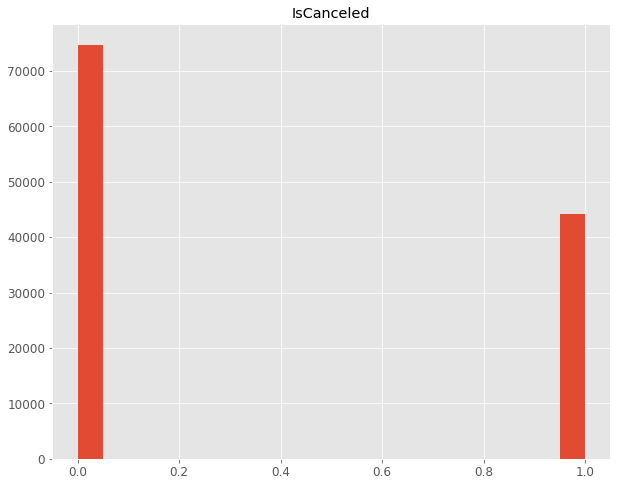

```
Coluna < LeadTime > tem:	0 valores NA.
```

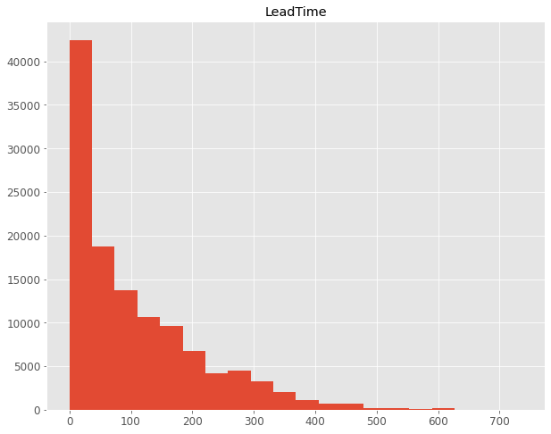

```
Coluna < ArrivalDateYear > tem:	0 valores NA.
```

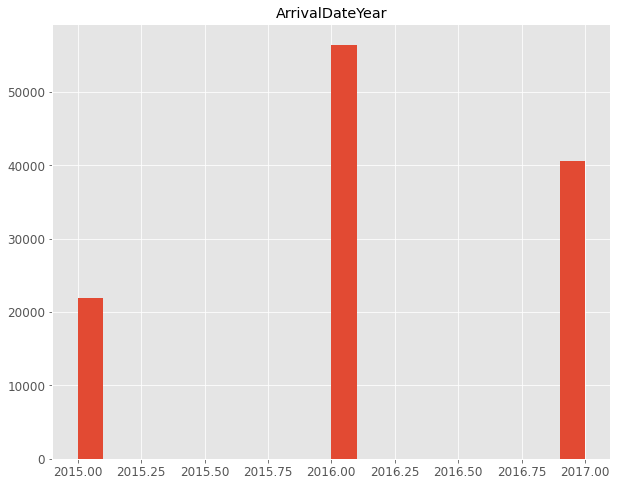

```
Coluna < ArrivalDateMonth > tem:	0 valores NA.
```

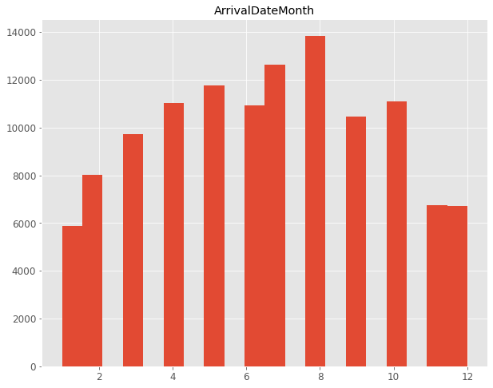

```
Coluna < ArrivalDateWeekNumber > tem:	0 valores NA.
```

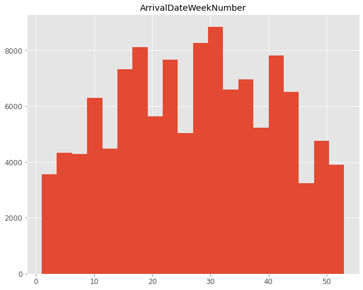

```
Coluna < ArrivalDateDayOfMonth > tem:	0 valores NA.
```

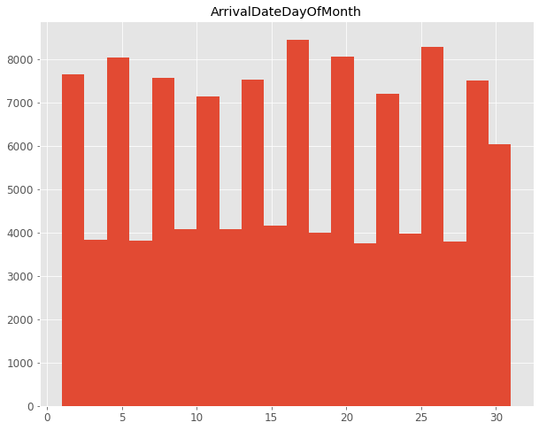

```
Coluna < StaysInWeekendNights > tem:	0 valores NA.
```

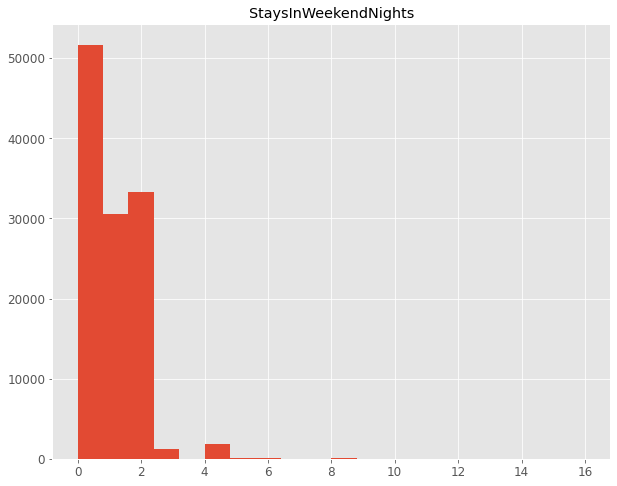

```
Coluna < StaysInWeekNights > tem:	0 valores NA.
```

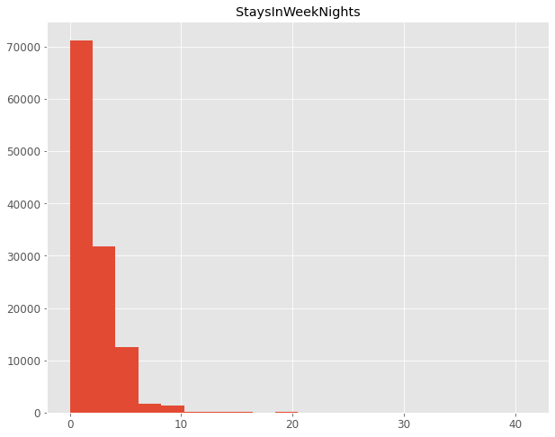

```
Coluna < Adults > tem:	0 valores NA.
```

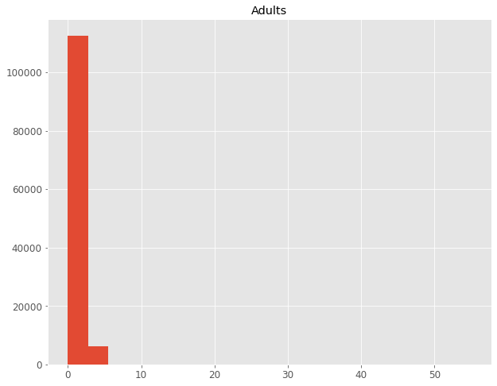

```
Coluna < Children > tem:	0 valores NA.
```

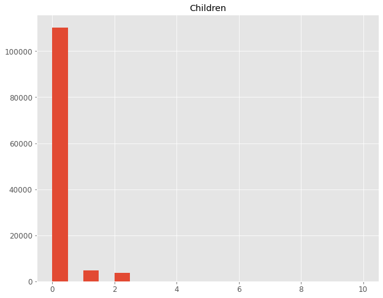

```
Coluna < Babies > tem:	0 valores NA.
```

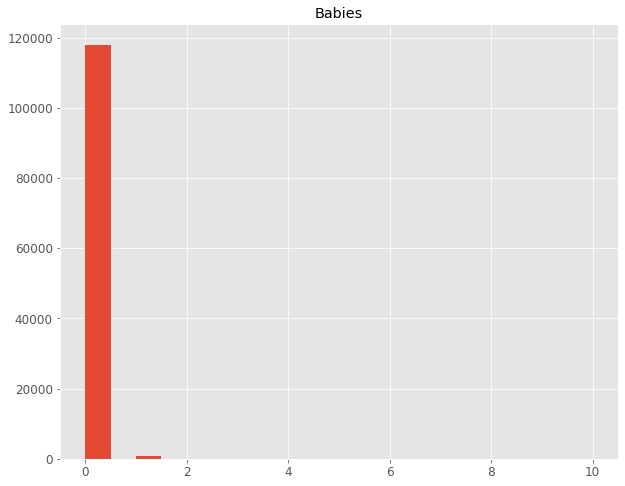

```
Coluna < Meal > tem:	0 valores NA.
```

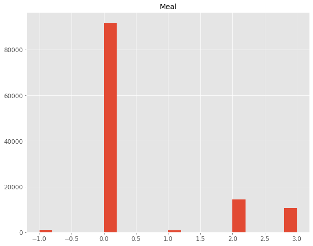

```
Coluna < Country > tem:	0 valores NA.
```

[19 more figures not shown]

```python
# Checa valores NA e cria alguns Plots
for column, series in dataset.items():
    print(f"Coluna < {column} > tem:\t{sum(series.isna())} valores NA.")
    plt.figure(figsize=[10,8])
    plt.hist(series, bins=20)
    plt.title(column)
    plt.show()
```

Tudo parece ok. Vamos verificar se temos algum prolema de colinearidade, ou seja, correlação muito alta entre as variáveis. Se tiver teremos que tomar alguma ação, pois a correlação é um problema.

```python
# Calcula a correlação
corr = dataset.corr()
```

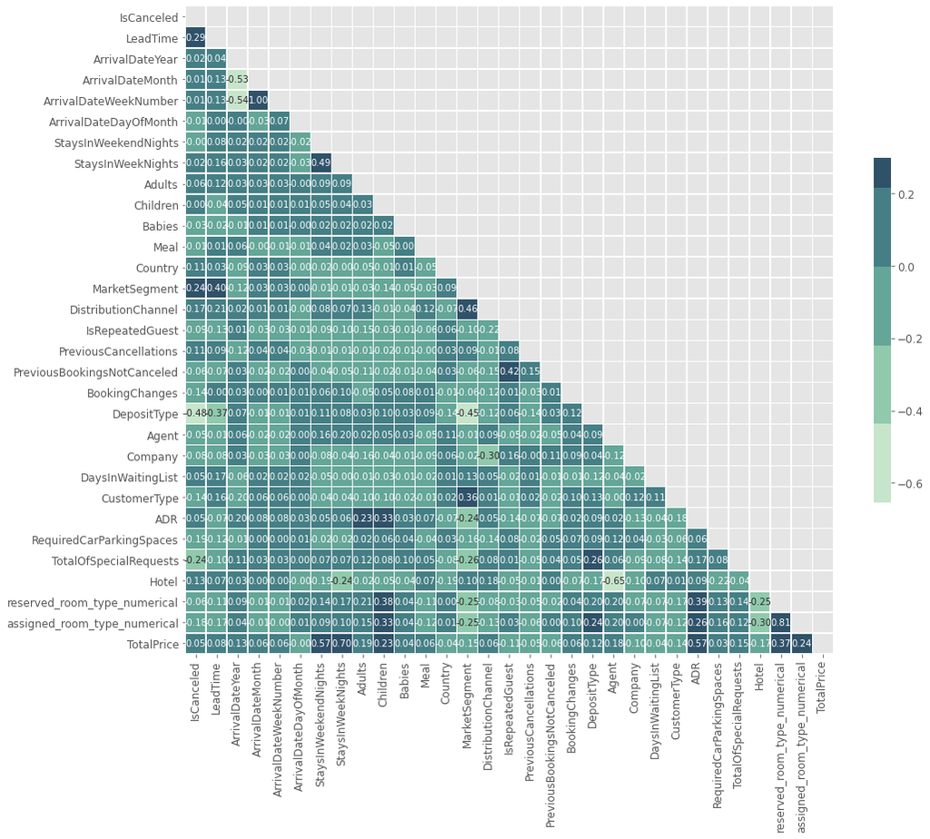

```python
# Plot da Matriz de Correlação

# Máscara
mask = np.triu(np.ones_like(corr, dtype = np.bool))

# Área de plotagem
f, ax = plt.subplots(figsize = (16, 14))

# Paleta de cores
cmap = sns.cubehelix_palette(rot=-.4)

# Mapa de calor com a correlação (Matriz de Correlação)
sns.heatmap(corr, mask = mask, cmap = cmap, vmax = .3, center = 0, annot = True, square = True,
            linewidths = .5, cbar_kws = {"shrink": .5}, fmt='.2f')
```

DepositType parede ter uma correlação negativa com a classificação IsCanceled, então resolvemos remover.

```python
# Drop que tem correlação no isCanceled.
dataset = dataset.drop(["DepositType"], 1)
```

```python
dataset.shape
```

```
(118894, 30)
```

## Pré-Processamento dos Dados

Limpeza concluída, podemos preparar os dados para treinamento.

```python
# Salva os dados 'limpos'.
dataset.to_pickle('datasetClean.pkl')
```

```python
# Analisa balanceamento da base. Talvez pudéssemos aplicar alguma técnica de balanceamento de dados como SMOTE por exemplo.
dataset["IsCanceled"].value_counts()
```

```
0    74742
1    44152
Name: IsCanceled, dtype: int64
```

```python
# Preparamos os dados de entrada em x
X = dataset.drop(["IsCanceled"], axis = 1)
```

```python
# Preparamos a variável de saída y
y = dataset["IsCanceled"]
```

## Valores base usando LogisticRegression e RandomForestClassifier

```python
# Dividimos os dados em treino e teste, com proporção 70/30
X_train, X_test, y_train, y_test = train_test_split(X, y, shuffle = True, test_size=.3, random_state=420)
```

```python
# Montar pipe para realizar o scaler aos dados de entrada de treino e executar o LR
pipe = make_pipeline(StandardScaler(), LogisticRegression(max_iter = 250, verbose=1))
```

```python
# Executa o pipeline
pipe.fit(X_train, y_train)
```

```
[Parallel(n_jobs=1)]: Using backend SequentialBackend with 1 concurrent workers.
[Parallel(n_jobs=1)]: Done   1 out of   1 | elapsed:    0.3s finished
```

```
Pipeline(steps=[('standardscaler', StandardScaler()),
                ('logisticregression',
                 LogisticRegression(max_iter=250, verbose=1))])
```

```python
# gerar analise
y_pred = pipe.predict(X_test)
print(accuracy_score(y_test, y_pred))
print(confusion_matrix(y_test, y_pred))
```

```
0.7786032689450223
[[19760  2664]
 [ 5233  8012]]
```

```python
# Aplicar a validação cruzada 10X
cross_val_score(pipe, X_test, y_test, cv=10).mean()
```

[output not shown]

```
0.7788276689118062
```

```python
# Montar pipe para realizar o scaler aos dados de entrada de treino e executar o RF
pipe = make_pipeline(StandardScaler(), RandomForestClassifier(verbose=1))
# Executa o pipeline
pipe.fit(X_train, y_train)
```

```
[Parallel(n_jobs=1)]: Using backend SequentialBackend with 1 concurrent workers.
[Parallel(n_jobs=1)]: Done 100 out of 100 | elapsed:   12.7s finished
```

```
Pipeline(steps=[('standardscaler', StandardScaler()),
                ('randomforestclassifier', RandomForestClassifier(verbose=1))])
```

```python
# gerar analise
y_pred = pipe.predict(X_test)
print(accuracy_score(y_test, y_pred))
print(confusion_matrix(y_test, y_pred))
```

```
[Parallel(n_jobs=1)]: Using backend SequentialBackend with 1 concurrent workers.
```

```
0.894193837786313
[[21150  1274]
 [ 2500 10745]]
```

```
[Parallel(n_jobs=1)]: Done 100 out of 100 | elapsed:    0.7s finished
```

```python
# Aplicar a validação cruzada 10X
cross_val_score(pipe, X_test, y_test, cv=10).mean()
```

[output not shown]

```
0.8772323053553317
```

```python
# Montar pipe para realizar o scaler aos dados de entrada de treino e executar o RF usando alguns parametros otimizados;
# pipe = make_pipeline(StandardScaler(), RandomForestClassifier(max_depth=20, max_features=5, min_samples_split=5, n_estimators=1000, verbose=1))

# pipe.fit(X_train, y_train)

# y_pred = pipe.predict(X_test)
# print(accuracy_score(y_test, y_pred))
# print(confusion_matrix(y_test, y_pred))
```

# Pré-Processamento dos Dados para aplicar no modelo deep

```python
# Convertemos para o tipo categórico
y = to_categorical(y, num_classes = None)
```

Dividimos os dados em treino e teste, com proporção 70/30

```python
# Divisão em treino e teste
X_treino, X_teste, y_treino, y_teste = train_test_split(X, y, shuffle = True, test_size = 0.3, random_state = 420)
```

```python
# Shape
print("Shape de X_treino =", X_treino.shape)
print("Shape de y_treino =", y_treino.shape)
print("Shape de X_teste =", X_teste.shape)
print("Shape de y_teste =", y_teste.shape)
```

```
Shape de X_treino = (83225, 29)
Shape de y_treino = (83225, 2)
Shape de X_teste = (35669, 29)
Shape de y_teste = (35669, 2)
```

Como as variáveis estão em escala diferente, vamos padronizar e deixar tudo na mesma escala. Fazemos isso somente com X.

```python
# Criamos o objeto scaler
scaler = MinMaxScaler()
```

```python
# Treinamos e Aplicamos o scaler aos dados de entrada de treino
X_treino = scaler.fit_transform(X_treino)
```

```python
# Aplicamos o scaler aos dados de entrada de teste
X_teste = scaler.transform(X_teste)
```

```python
# Resumo
print(f'Matriz da Variável de Entrada:\t{X.shape}\nMatriz da Variável de Saída:\t{y.shape}')
```

```
Matriz da Variável de Entrada:	(118894, 29)
Matriz da Variável de Saída:	(118894, 2)
```

## Construção do Modelo

Vamos criar o modelo de Deep Learning com 6 camadas densas, camadas de dropout para evitar o overfitting e ativação softmax para a classificação.

```python
# Criamos o modelo usando uma sequencia de BatchNormalization e Dropout.
modelo = Sequential()
modelo.add(Dense(128, input_dim = X.shape[1], activation = 'relu'))
modelo.add(BatchNormalization(momentum=0.8))
modelo.add(Dropout(0.1))
modelo.add(Dense(256, activation = 'relu'))
modelo.add(BatchNormalization(momentum=0.8))
modelo.add(Dropout(0.1))
modelo.add(Dense(1024, activation = 'relu'))
modelo.add(BatchNormalization(momentum=0.8))
modelo.add(Dropout(0.1))
modelo.add(Dense(512, activation = 'relu'))
modelo.add(BatchNormalization(momentum=0.8))
modelo.add(Dropout(0.1))
modelo.add(Dense(128, activation = 'relu'))
modelo.add(BatchNormalization(momentum=0.8))
modelo.add(Dropout(0.1))
modelo.add(Dense(2, activation = 'softmax'))
```

```python
# Usaremos como otimizador o algoritmo Nadam pois o conjunto de dados é complexo
# https://keras.io/api/optimizers/Nadam/
otimizador = Nadam(learning_rate = 0.0001,
                   beta_1 = 0.9,
                   beta_2 = 0.999,
                   epsilon = 1e-08)
```

```python
# Compilamos o modelo
modelo.compile(optimizer = otimizador, loss = 'categorical_crossentropy', metrics = ['accuracy'])
```

```python
# Vamos criar 2 callbacks
# Um para finalizar o treinamento se depois de 20 passadas o erro não mudar
# Outro para reduzir a taxa de aprendizagem se o erro não mudar após 5 passadas
callbacks = [EarlyStopping(monitor = "loss", patience = 20),
             ReduceLROnPlateau(monitor = "loss", patience = 5)]
```

```python
# Hiperparâmetros
num_epochs = 65
batch_size = 64
```

```python
# Treinamento

print("\nTreinamento Iniciado.\n")

history = modelo.fit(X_treino,
                     y_treino,
                     epochs = num_epochs,
                     batch_size = batch_size,
                     callbacks = callbacks)

print("\nTreinamento Concluído.\n")
```

```
Treinamento Iniciado.


Treinamento Concluído.
```

## Avaliação do Modelo

O treinamento ocorreu com sucesso. Vamos agora avaliar o modelo.

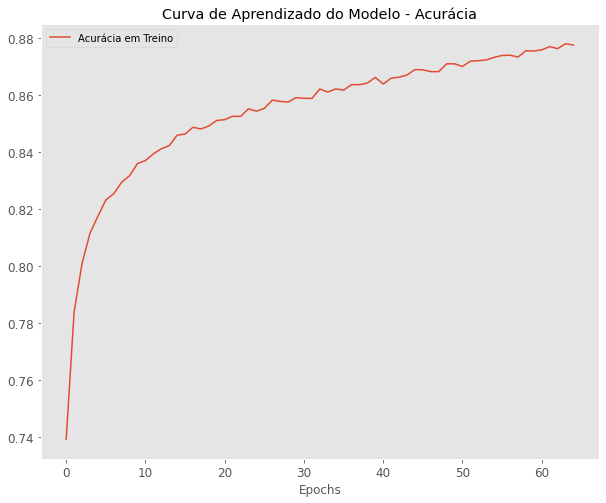

```python
# Plot da Acurácia em Treino
plt.figure(figsize = [10,8])
plt.title("Curva de Aprendizado do Modelo - Acurácia")
plt.plot(history.history['accuracy'], label = 'Acurácia em Treino')
plt.xlabel("Epochs")
plt.legend()
plt.grid()
plt.savefig('Acuracia-fitNew.png')
```

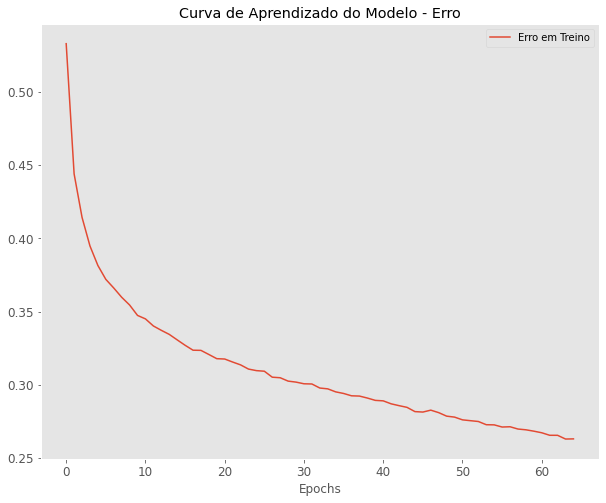

```python
# Plot do Erro em Treino
plt.figure(figsize = [10,8])
plt.title("Curva de Aprendizado do Modelo - Erro")
plt.plot(history.history['loss'], label = 'Erro em Treino')
plt.xlabel("Epochs")
plt.legend()
plt.grid()
plt.savefig('Erro-fitNew.png')
```

```python
# Fazemos as previsões com os dados de teste
previsoes = modelo.predict(X_teste)
```

```python
# Convertemos as previsões em previsões de classe
y_pred = (previsoes > 0.5)
```

```python
# Calculamos a acurácia comparando valor real com valor previsto
''' Resulado modelo RF
0.8772323053553317 (CV 10)
[[21150  1274]
 [ 2500 10745]]
'''
print(accuracy_score(y_teste, y_pred))
print(confusion_matrix(
    y_teste.argmax(axis=1), previsoes.argmax(axis=1)))
```

```
0.86537329333595
[[20161  2263]
 [ 2539 10706]]
```

Nosso modelo tem uma performance de ~86%

```python
# Salva o modelo
modelo.save("modelo/modeloNew.h5")
```